# **PROYEK SAINS DATA WATER QUALITY**

| Nama | : | Mubessirul Ummah |
| --- | --- | --- |
| NIM | : | 210411100140 |
| Kelas | : | Proyek Sains Data IF-5B |

[figure not shown]

# BUSINESS UNDERSTANDING

Tahapan business understanding merupakan tahap awal dari sebuah proyek data analytics. Tahapan ini akan dapat menghasilkan perencanaan sebuah proyek data analytics yang jelas tujuannya dan pemahaman menyeluruh tentang proses bisnis, seperti membuat peta rute untuk memastikan rencana yang baik. Berikut Business Understanding dari proyek saya kali ini :

## Determine Business Objectives (Menentukan Tujuan Bisnis)

Air merupakan salah satu sumber daya alam esensial untuk kelangsungan hidup seluruh makhluk hidup di dunia ini. Kita memerlukan air untuk kebutuhan kita sehari-hari, begitu juga dengan tanaman dan hewan yang memerlukan air untuk kelangsungan hidupnya. Menurut data dari World Health Organization (WHO), diperkirakan sebanyak 1.1 Miliar orang tidak memiliki akses untuk mendapatkan air yang layak minum dan 2.6 Miliar lainnya tidak mendapatkan fasilitas sanitasi yang baik. *Pengolahan data ini bertujuan untuk menilai dan mengategorikan kualitas air sebagai "aman" atau "tidak aman" menggunakan teknik klasifikasi*. Ini sejalan dengan tujuan lebih besar untuk memastikan air minum yang aman bagi masyarakat. Dalam pengolahan data kali ini akan dilakukan pencarian terhadap metode klasifikasi dan Apa fitur utama yang paling signifikan berkontribusi pada klasifikasi air sebagai aman atau tidak aman?

## Access Situation (Menilai Situasi)

Setelah memahami dengan lebih spesifik tujuan bisnis terkait penilaian kualitas air, langkah berikutnya adalah melakukan assessment yang mencakup ketersediaan sumber daya, mitigasi risiko, dan terutama ketersediaan data kualitas air. Data mengenai kualitas air dapat bervariasi tergantung pada sumbernya, dan metode analitika data yang akan diterapkan akan sangat dipengaruhi oleh ketersediaan data tersebut. Dalam konteks kualitas air, pertanyaan yang muncul adalah, "Apa fitur utama yang paling signifikan berkontribusi pada klasifikasi air sebagai aman atau tidak aman?" Untuk menjawab pertanyaan ini, metode klasifikasi atau estimasi dapat diterapkan. Misalnya, algoritma machine learning seperti Random Forest atau Logistic Regression dapat digunakan untuk mengidentifikasi faktor-faktor utama yang membedakan air aman dan tidak aman.

## Determine Data Mining Goals (Menentukan Tujuan Data Mining)

Tujuan Data Mining kali ini yakni untuk mengembangkan model klasifikasi yang dapat mengidentifikasi apakah suatu sampel air aman atau tidak aman berdasarkan parameter-parameter tertentu. Air minum yang layak konsumsi harus memenuhi beberapa kriteria, seperti tidak berwarna, tidak berbau, dan tidak mengandung zat berbahaya. Kriteria ini penting untuk diketahui agar terhindar dari masalah kesehatan akibat konsumsi air minum yang tidak layak. dalam menilai suatu air dikategorikan layak atau tidak layak di konsumsi jika berdasarkan kandungan zat yang ada di dalam air, maka berikut ini beberapa ciri atau kandungan air yang mempengaruhi kualitas air:

1. aluminium berbahaya jika lebih besar dari 2,8
2. ammonia berbahaya jika lebih besar dari 32,5
3. arsenic berbahaya jika lebih besar dari 0,01
4. barium berbahaya jika lebih besar dari 2
5. cadmium berbahaya jika lebih besar dari 0,005
6. chloramine berbahaya jika lebih besar dari 4
7. chromium berbahaya jika lebih besar dari 0,1
8. copper berbahaya jika lebih besar dari 1,3
9. flouride berbahaya jika lebih besar dari 1,5
10. bacteria berbahaya jika lebih besar dari 0
11. viruses berbahaya jika lebih besar dari 0
12. lead berbahaya jika lebih besar dari 0,015
13. nitrates berbahaya jika lebih besar dari 10
14. nitrites berbahaya jika lebih besar dari 1
15. mercury erbahaya jika lebih besar dari 0,002
16. perchlorate berbahaya jika lebih besar dari 56
17. radium berbahaya jika lebih besar dari 5
18. selenium berbahaya jika lebih besar dari 0,5
19. silver berbahaya jika lebih besar dari 0,1
20. uranium berbahaya jika lebih besar dari 0,3

Kemudian berdasarkan ciri-ciri di atas, suatu air bisa dikategorikan menjadi kelas 1 (safe atau aman) dan 0 (not safe atau tidak aman).

## Produce Project Plan (Menghasilkan Rencana Proyek)

Langkah-langkah Proyek sebagai berikut :

[figure not shown]

- Menentukan bussiness understanding
- Mengumpulkan dataset kualitas air yang mencakup informasi parameter-parameter yang sesuai.
- Melakukan data understanding untuk memahami sebuah data sepert jumlahnya, daftar kolom, tipe data kolom, banayknya kelas, dan mengetahui data tersebut perlu atau tidak untuk dilakukan preprocessing.
- Melakukan preprocessing terhadap dataset sebelum diterapkan teknik klasifikasi.
- Membagi dataset menjadi set pelatihan (training set) dan set pengujian (testing set).
- Menentukan teknik klasifikasi yang paling sesuai untuk proyek ini.
- Mengembangkan, melatih, dan mengevaluasi model klasifikasi menggunakan set pelatihan.
- Mengukur performa model menggunakan set pengujian.
- Melakukan evaluasi terhadap model yang telah dikembangkan.
- Mengimplementasikan model dalam aplikasi streamlit untuk mengetahui kualitas air.

```python
import matplotlib.pyplot as plt
import IPython
import numpy as np
import scipy.stats
import seaborn as sns
import pandas as pd
import os
from sklearn.preprocessing import MinMaxScaler
from sklearn.preprocessing import StandardScaler
import pickle
from sklearn.model_selection import train_test_split
from sklearn.metrics import accuracy_score
from sklearn.pipeline import Pipeline
from sklearn.model_selection import cross_validate
from sklearn.decomposition import PCA

from sklearn.ensemble import RandomForestClassifier
from sklearn.linear_model import LogisticRegression
# from keras.models import Sequential
# from keras.layers import Dense
from sklearn.tree import DecisionTreeClassifier
from sklearn.neighbors import KNeighborsClassifier
from sklearn.svm import SVC
from sklearn.ensemble import AdaBoostClassifier
from sklearn.naive_bayes import MultinomialNB
from sklearn.ensemble import RandomForestClassifier
from sklearn.ensemble import AdaBoostClassifier

from sklearn.feature_selection import mutual_info_classif
from sklearn.neighbors import LocalOutlierFactor
from imblearn.over_sampling import RandomOverSampler
from sklearn.preprocessing import RobustScaler
from collections import Counter

from sklearn.feature_selection import SelectKBest, f_classif
from sklearn.ensemble import RandomForestClassifier
from sklearn.metrics import accuracy_score
import joblib
from sklearn.preprocessing import RobustScaler
```

# DATA UNDERSTANDING

Data Understanding adalah tahap yang fokus pada eksplorasi dan pemahaman awal terhadap data yang akan digunakan dalam suatu proyek analisis data. Tahap ini merupakan langkah untuk memahami karakteristik, struktur, dan konten atau isi dari data sebelum melakukan analisis lebih lanjut. data understanding dipakai untuk memeriksa data sehingga dapat mengidentifikasi masalah pada data yang kita dapatkan.

## Deskripsi Dataset

Datasest waterquality merupakan kumpulan data yang dibuat dari data imajiner kualitas air di lingkungan perkotaan. Dataset ini mencakup data kadar mikroorganisme yang terkandung di dalam air seperti kadar aluminium, ammonia, arsenic, barium, cadmium, chloramine, chromium, copper, flouride, bacteria, viruses, lead, nitrates, nitrites, mercury, perchlorate, radium, selenium, silver, dan uranium. Data tersebut berisi 21 atribut dan 7999 record, record tersebut diberi label dengan variabel kelas is_safe, yang memungkinkan klasifikasi data menggunakan nilai 1 (safe atau aman) dan 0 (not_safe atau tidak aman) dikonsumsi. data ini saya dapatkan dari Kaggel dengan link berikut : https://www.kaggle.com/datasets/mssmartypants/water-quality/.

dataset tersebut berisi "synthetic water quality data" atau "simulated water quality data" atau dengan kata lain sample dari data yang bersifat fiktif atau imajiner yang dibuat untuk keperluan pendidikan dan latihan.

```python
# Membaca data dari file csv
df = pd.read_csv('waterQuality1.csv')
df
```

|  | aluminium | ammonia | arsenic | barium | cadmium | chloramine | chromium | copper | flouride | bacteria | ... | lead | nitrates | nitrites | mercury | perchlorate | radium | selenium | silver | uranium | is_safe |
| --- | --- | --- | --- | --- | --- | --- | --- | --- | --- | --- | --- | --- | --- | --- | --- | --- | --- | --- | --- | --- | --- |
| 0 | 1.65 | 9.08 | 0.04 | 2.85 | 0.007 | 0.35 | 0.83 | 0.17 | 0.05 | 0.20 | ... | 0.054 | 16.08 | 1.13 | 0.007 | 37.75 | 6.78 | 0.08 | 0.34 | 0.02 | 1 |
| 1 | 2.32 | 21.16 | 0.01 | 3.31 | 0.002 | 5.28 | 0.68 | 0.66 | 0.90 | 0.65 | ... | 0.100 | 2.01 | 1.93 | 0.003 | 32.26 | 3.21 | 0.08 | 0.27 | 0.05 | 1 |
| 2 | 1.01 | 14.02 | 0.04 | 0.58 | 0.008 | 4.24 | 0.53 | 0.02 | 0.99 | 0.05 | ... | 0.078 | 14.16 | 1.11 | 0.006 | 50.28 | 7.07 | 0.07 | 0.44 | 0.01 | 0 |
| 3 | 1.36 | 11.33 | 0.04 | 2.96 | 0.001 | 7.23 | 0.03 | 1.66 | 1.08 | 0.71 | ... | 0.016 | 1.41 | 1.29 | 0.004 | 9.12 | 1.72 | 0.02 | 0.45 | 0.05 | 1 |
| 4 | 0.92 | 24.33 | 0.03 | 0.20 | 0.006 | 2.67 | 0.69 | 0.57 | 0.61 | 0.13 | ... | 0.117 | 6.74 | 1.11 | 0.003 | 16.90 | 2.41 | 0.02 | 0.06 | 0.02 | 1 |
| ... | ... | ... | ... | ... | ... | ... | ... | ... | ... | ... | ... | ... | ... | ... | ... | ... | ... | ... | ... | ... | ... |
| 7994 | 0.05 | 7.78 | 0.00 | 1.95 | 0.040 | 0.10 | 0.03 | 0.03 | 1.37 | 0.00 | ... | 0.197 | 14.29 | 1.00 | 0.005 | 3.57 | 2.13 | 0.09 | 0.06 | 0.03 | 1 |
| 7995 | 0.05 | 24.22 | 0.02 | 0.59 | 0.010 | 0.45 | 0.02 | 0.02 | 1.48 | 0.00 | ... | 0.031 | 10.27 | 1.00 | 0.001 | 1.48 | 1.11 | 0.09 | 0.10 | 0.08 | 1 |
| 7996 | 0.09 | 6.85 | 0.00 | 0.61 | 0.030 | 0.05 | 0.05 | 0.02 | 0.91 | 0.00 | ... | 0.182 | 15.92 | 1.00 | 0.000 | 1.35 | 4.84 | 0.00 | 0.04 | 0.05 | 1 |
| 7997 | 0.01 | 10 | 0.01 | 2.00 | 0.000 | 2.00 | 0.00 | 0.09 | 0.00 | 0.00 | ... | 0.000 | 0.00 | 0.00 | 0.000 | 0.00 | 0.00 | 0.00 | 0.00 | 0.00 | 1 |
| 7998 | 0.04 | 6.85 | 0.01 | 0.70 | 0.030 | 0.05 | 0.01 | 0.03 | 1.00 | 0.00 | ... | 0.182 | 15.92 | 1.00 | 0.000 | 1.35 | 4.84 | 0.00 | 0.04 | 0.05 | 1 |

7999 rows × 21 columns

Kode di atas digunakan untuk membuka file csv dan menampilkan visual isi dari dataset.

```python
print("Banyaknya data : ", df.shape[0])
print("Banyaknya kolom : ", df.shape[1])
```

```
Banyaknya data :  7999
Banyaknya kolom :  21
```

fungs shape sendiri digunakan untuk mengetahui dimensi dari dataframe atau ukuran baris dan kolomnya. df.shape[0]: Ini mencetak jumlah baris (data points) dalam DataFrame df. Dalam hal ini, jumlah barisnya adalah 7999. df.shape[1]: Ini mencetak jumlah kolom (fitur atau variabel) dalam DataFrame df. Dalam hal ini, jumlah kolomnya adalah 21. Dengan kata lain, DataFrame Anda memiliki 7999 baris dan 21 kolom.

## Deskripsi Fitur Dataset

1. **Aluminium** : Merupakan kandungan aluminium dalam air. berbahaya jika lebih besar dari 2,8. kandungan aluminium yang berlebihan dapat menyebabkan masalah kesehatan, terutama pada sistem saraf.
2. **Ammonia** : Kandungan ammonia (NH3) dalam air. Amonia adalah gas dengan bau yang tajam dan beracun dalam konsentrasi tinggi. berbahaya jika lebih besar dari 32,5. Kandungan ammonia yang tinggi dalam air dapat menyebabkan kerusakan organisme akuatik dan merusak kualitas air minum.
3. **Arsenic** : Kandungan arsenik dalam air. Arsenic adalah unsur kimia dalam tabel periodik dengan simbol As dan nomor atom 33. Arsenic dapat ditemukan secara alami di dalam kerak bumi dan digunakan dalam berbagai aplikasi industri, termasuk pembuatan kayu tahan air. arsenic berbahaya jika lebih besar dari 0,01. Kandungan arsenik yang tinggi dalam air minum dapat menyebabkan keracunan dan meningkatkan risiko kanker.
4. **Barium**: Kandungan barium dalam air. Barium adalah unsur kimia dengan simbol Ba dan nomor atom 56. Barium digunakan dalam industri minyak dan gas, serta dalam radiografi medis. berbahaya jika lebih besar dari 2. Pemaparan jangka panjang terhadap barium dapat menyebabkan kerusakan organ dalam tubuh manusia.
5. **Cadmium** : Kandungan kadmium dalam air. Cadmium adalah unsur kimia dengan simbol Cd dan nomor atom 48. Cadmium digunakan dalam baterai, cat, dan plastik. berbahaya jika lebih besar dari 0,005. Pemaparan cadmium dapat menyebabkan masalah kesehatan serius, termasuk kerusakan ginjal dan kanker.
6. **Chloramine** : Kandungan chloramine dalam air. Chloramine adalah senyawa kimia yang terbentuk dari klorin dan amonia. Ini digunakan sebagai desinfektan dalam air minum. berbahaya jika lebih besar dari 4. Paparan kloramine dalam jumlah yang tinggi dapat menyebabkan iritasi mata dan tenggorokan.
7. **Chromium** : Kandungan kromium dalam air. berbahaya jika lebih besar dari 0,1. Pemaparan kromium VI dapat menyebabkan kerusakan paru-paru, penyakit pernapasan, dan kanker.
8. **Copper** : Kandungan tembaga dalam air. Copper adalah unsur kimia dengan simbol Cu dan nomor atom 29. Copper digunakan dalam instalasi listrik, pipa, dan peralatan masak. berbahaya jika lebih besar dari 1,3. Kandungan tembaga yang berlebihan dalam air minum dapat menyebabkan gangguan pencernaan dan masalah hati.
9. **Fluoride** : Kandungan fluoride dalam air. Fluoride adalah ion anorganik yang penting untuk kesehatan gigi. berbahaya jika lebih besar dari 1,5. konsumsi fluoride dalam jumlah yang berlebihan dapat menyebabkan masalah kesehatan gigi dan tulang.
10. **Bacteria** : Indikator keberadaan bakteri dalam air. Bakteri adalah mikroorganisme yang dapat ditemukan dalam air. berbahaya jika lebih besar dari 0.
11. **Viruses** : Indikator keberadaan virus dalam air. berbahaya jika lebih besar dari 0
12. **Lead** : Kandungan timbal dalam air. Lead adalah logam berat yang dapat menyebabkan keracunan, terutama pada anak-anak. berbahaya jika lebih besar dari 0,015. Pemaparan timbal dapat menyebabkan kerusakan otak dan sistem saraf.
13. **Nitrates** : Kandungan nitrat dalam air. Nitrates adalah senyawa kimia yang dapat ditemukan dalam pupuk dan limbah industriberbahaya jika lebih besar dari 10. Kandungan nitrates yang tinggi dalam air dapat menyebabkan masalah kesehatan, terutama pada bayi.
14. **Nitrites** : Kandungan nitrit dalam air. nitrites adalah senyawa kimia yang dapat ditemukan dalam pupuk dan limbah industriberbahaya jika lebih besar dari 1. Kandungan nitrites yang tinggi dalam air dapat menyebabkan masalah kesehatan, terutama pada bayi.
15. **Mercury** : Kandungan merkuri dalam air. Mercury adalah logam berat yang dapat mengakumulasi dalam organisme hidup dan menyebabkan keracunan. berbahaya jika lebih besar dari 0,002. Pemaparan merkuri dapat merusak otak, ginjal, dan sistem saraf.
16. **Perchlorate** : Kandungan perchlorate dalam air. Perchlorate adalah senyawa kimia yang digunakan dalam bahan peledak dan propelan roket. Pemaparan perchlorate dapat mengganggu fungsi tiroid. berbahaya jika lebih besar dari 56
17. **Radium** : Kandungan radium dalam air. Radium adalah unsur radioaktif yang dapat ditemukan secara alami dalam tanah dan air. Paparan radium dapat meningkatkan risiko kanker. berbahaya jika lebih besar dari 5
18. **Selenium** : Kandungan selenium dalam air. berbahaya jika lebih besar dari 0,5. konsumsi selenium yang berlebihan dapat menyebabkan masalah kesehatan, termasuk kerusakan saraf.
19. **Silver** : Kandungan perak dalam air. berbahaya jika lebih besar dari 0,1. Konsumsi perak dalam jumlah yang berlebihan dapat menyebabkan argyria, kondisi di mana kulit manusia berubah menjadi warna biru keabu-abuan.
20. **Uranium** : Kandungan uranium dalam air. Uranium adalah unsur radioaktif yang dapat ditemukan secara alami dalam batuan dan air. Paparan uranium dapat meningkatkan risiko kanker dan masalah ginjal. berbahaya jika lebih besar dari 0,3
21. **Is_safe** : Kolom ini adalah label atau target variabel yang menunjukkan apakah sampel air tersebut aman untuk dikonsumsi atau tidak. class attribute {0 - not safe, 1 - safe}

fitur di atas ini mencerminkan kandungan berbagai mikroorganisme dalam air. Dalam setiap fitur atau kandungan yang ada dalam air tersebut memiliki batasan aman. jika kandungan mikroorganisme melebihi nilai-nilai batasan ini, air dianggap tidak aman untuk konsumsi manusia.

```python
df.columns
```

```
Index(['aluminium', 'ammonia', 'arsenic', 'barium', 'cadmium', 'chloramine',
       'chromium', 'copper', 'flouride', 'bacteria', 'viruses', 'lead',
       'nitrates', 'nitrites', 'mercury', 'perchlorate', 'radium', 'selenium',
       'silver', 'uranium', 'is_safe'],
      dtype='object')
```

fungsi columns digunakan untuk menampilkan nama-nama kolom pada dataframe. yang mana dataset water quality ini terdiri dari 21 kolom, yakni aluminium, ammonia, arsenic, barium, cadmium, chloramine, chromium, copper, flouride, bacteria, viruses, lead, nitrates, nitrites, mercury, perchlorate, radium, selenium, silver, uranium, dan is_safe.

```python
df.describe()
```

|  | aluminium | arsenic | barium | cadmium | chloramine | chromium | copper | flouride | bacteria | viruses | lead | nitrates | nitrites | mercury | perchlorate | radium | selenium | silver | uranium |
| --- | --- | --- | --- | --- | --- | --- | --- | --- | --- | --- | --- | --- | --- | --- | --- | --- | --- | --- | --- |
| count | 7999.000000 | 7999.000000 | 7999.000000 | 7999.000000 | 7999.000000 | 7999.000000 | 7999.000000 | 7999.000000 | 7999.000000 | 7999.000000 | 7999.000000 | 7999.000000 | 7999.000000 | 7999.000000 | 7999.000000 | 7999.000000 | 7999.000000 | 7999.000000 | 7999.000000 |
| mean | 0.666158 | 0.161445 | 1.567715 | 0.042806 | 2.176831 | 0.247226 | 0.805857 | 0.771565 | 0.319665 | 0.328583 | 0.099450 | 9.818822 | 1.329961 | 0.005194 | 16.460299 | 2.920548 | 0.049685 | 0.147781 | 0.044673 |
| std | 1.265145 | 0.252590 | 1.216091 | 0.036049 | 2.567027 | 0.270640 | 0.653539 | 0.435373 | 0.329485 | 0.378096 | 0.058172 | 5.541331 | 0.573219 | 0.002967 | 17.687474 | 2.323009 | 0.028770 | 0.143551 | 0.026904 |
| min | 0.000000 | 0.000000 | 0.000000 | 0.000000 | 0.000000 | 0.000000 | 0.000000 | 0.000000 | 0.000000 | 0.000000 | 0.000000 | 0.000000 | 0.000000 | 0.000000 | 0.000000 | 0.000000 | 0.000000 | 0.000000 | 0.000000 |
| 25% | 0.040000 | 0.030000 | 0.560000 | 0.008000 | 0.100000 | 0.050000 | 0.090000 | 0.405000 | 0.000000 | 0.002000 | 0.048000 | 5.000000 | 1.000000 | 0.003000 | 2.170000 | 0.820000 | 0.020000 | 0.040000 | 0.020000 |
| 50% | 0.070000 | 0.050000 | 1.190000 | 0.040000 | 0.530000 | 0.090000 | 0.750000 | 0.770000 | 0.220000 | 0.008000 | 0.102000 | 9.930000 | 1.420000 | 0.005000 | 7.740000 | 2.410000 | 0.050000 | 0.080000 | 0.050000 |
| 75% | 0.280000 | 0.100000 | 2.480000 | 0.070000 | 4.240000 | 0.440000 | 1.390000 | 1.160000 | 0.610000 | 0.700000 | 0.151000 | 14.610000 | 1.760000 | 0.008000 | 29.480000 | 4.670000 | 0.070000 | 0.240000 | 0.070000 |
| max | 5.050000 | 1.050000 | 4.940000 | 0.130000 | 8.680000 | 0.900000 | 2.000000 | 1.500000 | 1.000000 | 1.000000 | 0.200000 | 19.830000 | 2.930000 | 0.010000 | 60.010000 | 7.990000 | 0.100000 | 0.500000 | 0.090000 |

Fungsi describe() digunakan untuk menampilkan statistik deskriptif dari data frame atau series. Output dari fungsi ini berisi rangkuman central tendency dan sebaran dari dataset. Fungsi describe() membantu kita untuk mendapatkan overview dari dataset. Di bawah ini adalah penjelasan hasil yang diberikan:

- Count (Jumlah): Menunjukkan jumlah data yang ada dalam setiap kolom. Misalnya, pada kolom "aluminium", terdapat 7999 data.
- Mean (Rata-rata): Menunjukkan nilai rata-rata dari setiap kolom. Misalnya, rata-rata kandungan aluminium adalah sekitar 0.666158.
- Std (Standar Deviasi): Menunjukkan sejauh mana nilai-nilai dalam kolom tersebar dari rata-rata. Semakin tinggi standar deviasi, semakin besar variabilitasnya dari rata-rata. Misalnya, standar deviasi kandungan aluminium adalah sekitar 1.265145.
- Min (Minimum): Menunjukkan nilai terkecil dalam setiap kolom. Misalnya, nilai minimum kandungan arsenik adalah 0.0.
- 25% (Kuartil Pertama): Menunjukkan nilai yang membagi 25% data terendah dari nilai-nilai lainnya. Misalnya, pada kolom "aluminium", 25% data berada di bawah 0.040000.
- 50% (Median atau Kuartil Kedua): Menunjukkan nilai yang membagi dataset menjadi dua bagian setara, atau median. Misalnya, median kandungan aluminium adalah 0.070000.
- 75% (Kuartil Ketiga): Menunjukkan nilai yang membagi 75% data terendah dari nilai-nilai lainnya. Misalnya, pada kolom "aluminium", 75% data berada di bawah 0.280000.
- Max (Maksimum): Menunjukkan nilai tertinggi dalam setiap kolom. Misalnya, nilai maksimum kandungan aluminium adalah 5.050000.

## Deskripsi Tipe Data Fitur

Berikut adalah analisis tipe data untuk setiap kolom beserta alasannya:

1. aluminium: Tipe data rasio. Kandungan aluminium dalam air memiliki nol yang bermakna, dan perbandingan antara dua nilai memiliki arti yang jelas (misalnya, 2 kali lipat).
2. ammonia: Tipe data rasio. Kandungan ammonia dalam air juga memiliki nol yang bermakna dan perbandingan antara dua nilai memiliki arti yang jelas.
3. arsenic: Tipe data rasio. Kandungan arsenik dalam air memiliki nol yang bermakna dan perbandingan antara dua nilai memiliki arti yang jelas.
4. barium: Tipe data rasio. Kandungan barium dalam air memiliki nol yang bermakna dan perbandingan antara dua nilai memiliki arti yang jelas.
5. cadmium: Tipe data rasio. Kandungan cadmium dalam air memiliki nol yang bermakna dan perbandingan antara dua nilai memiliki arti yang jelas.
6. chloramine: Tipe data rasio. Kandungan chloramine dalam air memiliki nol yang bermakna dan perbandingan antara dua nilai memiliki arti yang jelas.
7. chromium: Tipe data rasio. Kandungan chromium dalam air memiliki nol yang bermakna dan perbandingan antara dua nilai memiliki arti yang jelas.
8. copper: Tipe data rasio. Kandungan copper dalam air memiliki nol yang bermakna dan perbandingan antara dua nilai memiliki arti yang jelas.
9. flouride: Tipe data rasio. Kandungan flouride dalam air memiliki nol yang bermakna dan perbandingan antara dua nilai memiliki arti yang jelas.
10. bacteria: Tipe data rasio. Kandungan bakteri dalam air memiliki nol yang bermakna dan perbandingan antara dua nilai memiliki arti yang jelas.
11. viruses: Tipe data rasio. Kandungan virus dalam air memiliki nol yang bermakna dan perbandingan antara dua nilai memiliki arti yang jelas.
12. lead: Tipe data rasio. Kandungan lead dalam air memiliki nol yang bermakna dan perbandingan antara dua nilai memiliki arti yang jelas.
13. nitrates: Tipe data rasio. Kandungan nitrates dalam air memiliki nol yang bermakna dan perbandingan antara dua nilai memiliki arti yang jelas.
14. nitrites: Tipe data rasio. Kandungan nitrites dalam air memiliki nol yang bermakna dan perbandingan antara dua nilai memiliki arti yang jelas.
15. mercury: Tipe data rasio. Kandungan mercury dalam air memiliki nol yang bermakna dan perbandingan antara dua nilai memiliki arti yang jelas.
16. perchlorate: Tipe data rasio. Kandungan perchlorate dalam air memiliki nol yang bermakna dan perbandingan antara dua nilai memiliki arti yang jelas.
17. radium: Tipe data rasio. Kandungan radium dalam air memiliki nol yang bermakna dan perbandingan antara dua nilai memiliki arti yang jelas.
18. selenium: Tipe data rasio. Kandungan selenium dalam air memiliki nol yang bermakna dan perbandingan antara dua nilai memiliki arti yang jelas.
19. silver: Tipe data rasio. Kandungan silver dalam air memiliki nol yang bermakna dan perbandingan antara dua nilai memiliki arti yang jelas.
20. uranium: Tipe data rasio. Kandungan uranium dalam air memiliki nol yang bermakna dan perbandingan antara dua nilai memiliki arti yang jelas.
21. is_safe: Tipe data nominal. Variabel target ini merupakan label kategori yang menunjukkan apakah air layak diminum atau tidak. Ini merupakan tipe data kategorikal dengan dua kategori yang bersifat nominal.

## Identifikasi Missing Value

(Dataset ini memiliki 3 missing value pada kolom amonia dan is_safe) penjelasannya sebagai berikut :

Identifikasi missing value adalah proses mengenali dan menentukan lokasi di mana nilai-nilai yang hilang (missing value) terdapat dalam dataset. untuk mencari missing value kita bisa menggunakan fungsi info(). Fungsi info() digunakan untuk menampilkan informasi detail tentang dataframe, seperti jumlah baris data, nama-nama kolom berserta jumlah data dan tipe datanya, dan sebagainya. Dimana didapat bahwa dataset tersebut nampaknya tidak memiliki nilai yang missing karena nilai non-null setiap kolomnya sebanyak 7999 sama dengan jumlah dataset sebenarnya. akan tetapi perlu di telisik lebih dalam karena bisa jadi valuenya terdapat kerusakan seperti yang awalnya berupa angka, akan tetapi berubah menjadi stringg atau object, dimana itu terdeteksi pada kolom amonia dan is_safe.

```python
df.info()
```

```
<class 'pandas.core.frame.DataFrame'>
RangeIndex: 7999 entries, 0 to 7998
Data columns (total 21 columns):
 #   Column       Non-Null Count  Dtype
---  ------       --------------  -----
 0   aluminium    7999 non-null   float64
 1   ammonia      7999 non-null   object
 2   arsenic      7999 non-null   float64
 3   barium       7999 non-null   float64
 4   cadmium      7999 non-null   float64
 5   chloramine   7999 non-null   float64
 6   chromium     7999 non-null   float64
 7   copper       7999 non-null   float64
 8   flouride     7999 non-null   float64
 9   bacteria     7999 non-null   float64
 10  viruses      7999 non-null   float64
 11  lead         7999 non-null   float64
 12  nitrates     7999 non-null   float64
 13  nitrites     7999 non-null   float64
 14  mercury      7999 non-null   float64
 15  perchlorate  7999 non-null   float64
 16  radium       7999 non-null   float64
 17  selenium     7999 non-null   float64
 18  silver       7999 non-null   float64
 19  uranium      7999 non-null   float64
 20  is_safe      7999 non-null   object
dtypes: float64(19), object(2)
memory usage: 1.3+ MB
```

Kita akan mengecek apakah sebuah data mengandung Pesan "#NUM!". #NUM! mungkin muncul karena adanya kesalahan atau format yang tidak tepat dalam dataset, terutama pada kolom yang seharusnya berisi nilai numerik. Tanda ini seringkali menunjukkan bahwa suatu sel atau entri dalam dataset tidak dapat diuraikan sebagai nilai numerik yang valid.

```python
# Menghitung apakah ada nilai '#NUM!' dalam setiap kolom
contains_num = df.eq('#NUM!')

# Menampilkan hasil
print("Apakah ada nilai '#NUM!' dalam setiap kolom:")
print(contains_num.any())

# Menghitung jumlah nilai '#NUM!' untuk setiap kolom
num_count_per_column = contains_num.sum()
print("Jumlah nilai '#NUM!' untuk setiap kolom:")
print(num_count_per_column)
```

```
Apakah ada nilai '#NUM!' dalam setiap kolom:
aluminium      False
ammonia         True
arsenic        False
barium         False
cadmium        False
chloramine     False
chromium       False
copper         False
flouride       False
bacteria       False
viruses        False
lead           False
nitrates       False
nitrites       False
mercury        False
perchlorate    False
radium         False
selenium       False
silver         False
uranium        False
is_safe         True
dtype: bool
Jumlah nilai '#NUM!' untuk setiap kolom:
aluminium      0
ammonia        3
arsenic        0
barium         0
cadmium        0
chloramine     0
chromium       0
copper         0
flouride       0
bacteria       0
viruses        0
lead           0
nitrates       0
nitrites       0
mercury        0
perchlorate    0
radium         0
selenium       0
silver         0
uranium        0
is_safe        3
dtype: int64
```

Kode di atas ini digunakan untuk mengakumulasi dengan melakukan pengecekan apakah terdapat nilai yang hilang (NaN) dalam kolom yang ada dalam DataFrame (df).

- Fungsi eq (singkatan dari "equal") pada Pandas digunakan untuk membandingkan elemen-elemen dalam suatu DataFrame atau Series dengan nilai tertentu dan mengembalikan DataFrame atau Series baru yang berisi nilai True jika elemennya sama dengan nilai yang dibandingkan, dan False jika tidak.
- Fungsi any() fungsi any() pada Pandas digunakan untuk menentukan apakah setidaknya satu elemen dalam suatu DataFrame atau Series memiliki nilai True. Jika ada setidaknya satu nilai True, maka fungsi any() akan mengembalikan True; sebaliknya, jika semua nilai adalah False, maka akan mengembalikan False.
- fungsi sum() fungsi sum() pada pandas digunakan untuk menjumlahkan suatu data, dimana fungsi ini digunakan untuk menghitung jumlah nilai True (jumlah nilai '#NUM!') dalam setiap kolom dan menyimpannya dalam suatu variable untuk kemudian ditampilkan.

Berdasarkan identifikasi lebih dalam maka didapati nilai yang hilang berupa #NUM! Dalam dataset water quality ini memiliki 3 missing value pada kolom amonia dan is_safe.

## Identifikasi Data Duplicated

Identifikasi data duplikat merujuk pada proses menemukan dan menandai baris atau entri dalam dataset yang memiliki nilai yang sama di semua kolomnya. Dengan kata lain, data duplikat adalah duplikat persis dari baris lainnya dalam dataset. Dalam dataset water Quality ini tidak ditemukannya data duplikat.

```python
jumlah_duplikat = df.duplicated().sum()

# Menampilkan jumlah data yang duplikat
print("Jumlah data yang duplikat:", jumlah_duplikat)
```

```
Jumlah data yang duplikat: 0
```

Kode diatas yakni digunakan untuk mengidentifikasi dan menghitung jumlah data duplikat dalam DataFrame (df). Menggunakan metode duplicated() untuk menghasilkan keterangan boolean yang menunjukkan apakah setiap baris dalam DataFrame adalah duplikat dari baris sebelumnya atau tidak (True atau False). Kemudian, metode sum() digunakan untuk menghitung jumlah total nilai True, yang merupakan jumlah total data duplikat. Dalam dataset saya, tidak ada data yang mengalami duplikasi data.

Contoh deteksi duplikat data : | A | B | |---|--------| | 1 | apple | | 2 | banana | | 3 | apple | | 2 | banana | | 4 | orange |

Baris-baris yang merupakan duplikat:

- 0 False
- 1 False
- 2 False
- 3 True
- 4 False

## Identifikasi Sebaran Kelas Data

identifikasi ini digunakan untuk melihat sejauh mana perbedaan jumlah kedua kelas yakni kelas 0 atau tidak aman, dan kelas 1 atau aman. Dalam dataset Water Quality ini mengalamni unbalance data, dimana terdapat perbedaan yang cukup signifikan dalam jumlah data tiap kelasnya. Data dengan kelas 0 atau tidak aman berjumlah 7084 berbanding cukup jauh dengan data dengan kelas 1 yang hanya berkisar 912 data saja. Oleh karena itu, perlu dilakukan pre-processing untuk menyamaratakan jumlah data setiap kelasnya.

Menurut He dan Edwardo (2009) sebuah himpunan data dikatakan imbalanced jika terdapat salah satu kelas yang direpresentasikan dalam jumlah yang tidak sebanding dengan kelas yang lain. Kondisi imbalanced data menjadi masalah dalam klasifikasi karena classifier learning akan condong memprediksi ke kelas data yang banyak (mayoritas) dibanding dengan kelas yang sedikit (minoritas). Akibatnya, dihasilkan akurasi prediksi yang baik terhadap kelas data training yang banyak (kelas mayoritas) sedangkan untuk kelas data training yang sedikit (kelas minoritas) akan dihasilkan akurasi prediksi yang buruk.

Imbalanced data dapat diatasi dengan beberapa cara, antara lain dengan pengambilan sampel pada setiap kelas dan strategi sampling seperti oversampling atau undersampling.

```python
df = pd.read_csv('waterQuality1.csv')
```

```python
print(df['is_safe'].unique())
print(df.is_safe.value_counts())
```

```
['1' '0' '#NUM!']
0        7084
1         912
#NUM!       3
Name: is_safe, dtype: int64
```

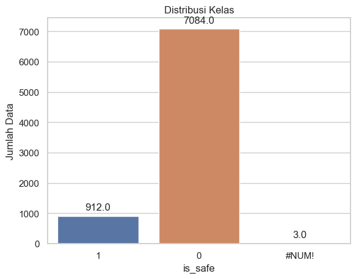

```python
import seaborn as sns
import matplotlib.pyplot as plt

# Menggunakan seaborn untuk membuat countplot
sns.set(style="whitegrid")
ax = sns.countplot(data=df, x='is_safe')

# Menambahkan label pada sumbu y
plt.ylabel('Jumlah Data')

# Menambahkan judul plot
plt.title('Distribusi Kelas')

# Menampilkan jumlah data untuk masing-masing kelas di atas batangnya
for p in ax.patches:
    ax.annotate(f'{p.get_height()}', (p.get_x() + p.get_width() / 2., p.get_height()),
                ha='center', va='center', xytext=(0, 10), textcoords='offset points')

# Menampilkan plot
plt.show()
```

Kode diatas menggunakan seaborn dan matplotlib untuk membuat countplot dari kolom 'is_safe' dalam DataFrame df. Hasilnya adalah visualisasi distribusi kelas 'is_safe' dengan jumlah data di setiap kategori.

## Identifikasi Outlier

Identifikasi Outlier kali ini menggunakan Metode Local Outlier Factor. Local Outlier Factor (LOF) adalah metode yang digunakan untuk mendeteksi outlier dalam dataset. Data dalam dataset water quality yang mengalami outlier adalah sebanyak 1999 data.

Metode Local Outlier Factor (LOF) membandingkan kerapatan suatu titik data dengan kerapatan titik-titik di sekitarnya. LOF mengukur sejauh mana suatu titik data dianggap anomali atau outlier berdasarkan perbedaan kerapatan. Metode ini dikembangkan oleh Markus M. Breunig, Hans-Peter Kriegel, Raymond T. Ng, dan Jörg Sander pada tahun 2000. [Sumber](https://en.wikipedia.org/wiki/Local_outlier_factor)

Berikut adalah langkah-langkah Local Outlier Factor (LOF):

1. Hitung jarak antar titik dan tetangga
- Rumus jarak euclidean antara dua titik p dan 1 dalam dimensi n: \begin{equation} \text{Euclidean Distance} (P, Q) = \sqrt{\sum_{i=1}^{n} (q_i - p_i)^2} \end{equation} \begin{equation} \text{Euclidean Distance} (P, Q) = \sqrt{(q_1 - p_1)^2 + (q_2 - p_2)^2} \end{equation}
1. Hitung kepadatan lokasi
- Kepadatan lokal suatu titik p: \begin{equation} \text{Density}_p = \frac{1}{{\text{k-th distance}_p}} \end{equation} \begin{equation} {{\text{Dimana k-th distance adalah jarak ke titik tetangga ke-k}_p}} \end{equation}
1. Hitung Local Reachability Density (LRD)
- Local Reachability Density (LRD) suatu titik p: \begin{equation} \text{LRD}_p = \left(\text{Density}_p\right)^{\frac{1}{\alpha}} \end{equation} di mana α adalah parameter untuk menyesuaikan sensitivitas terhadap fluktuasi kecil dalam kepadatan.
1. Hitung Local Outlier Factor (LOF)
- Local Outlier Factor (LOF) suatu titik p: \begin{equation} \text{LOF}_p = \frac{\left|\text{Neighbors}_p\right|}{\sum_{o \in \text{Neighbors}_p} \frac{\text{LRD}_o}{\text{LRD}_p}} \end{equation} di mana Neighborsp adalah himpunan tetangga dari titik p.
1. Identifikasi Outlier: Tentukan threshold, dan labeli titik-titik yang memiliki LOF di atas threshold sebagai outlier. Pada umumnya, jika LOF(p) > Threshold, maka titik p dianggap sebagai outlier.

Contoh Kasus, untuk mencari outlier pada data misalkan terdapat tabel seperti dibawah ini:

[output not shown]

- Langkah 1 : Hitung Jarak Antar Data lalu nilai radius yang diambil adalah 5

| X | Y | Jarak |
| --- | --- | --- |
| 1 | 4 | 1,41 ; 4,47 ; 4,47 |
| 2 | 3 | 1,41 ; 3,16 |
| 3 | 8 | 4,47 |
| 5 | 2 | 4,47 ; 3,16 ; 4,24 |
| 8 | 5 | 4,24 |

- Langkah 2 : Hitung jumlah tetangga dalam radius 5

| X | Y | Jumlah Tetangga |
| --- | --- | --- |
| 1 | 4 | 3 |
| 2 | 3 | 2 |
| 3 | 8 | 1 |
| 5 | 2 | 3 |
| 8 | 5 | 1 |

- Langkah 3 : Hitung Local Reachability Density

| X | Y | Jarak |
| --- | --- | --- |
| 1 | 4 | (1,41 + 4,47 + 4,47) / 3 = 3,45 |
| 2 | 3 | (1,41 + 3,16) /2 = 2,285 |
| 3 | 8 | 4,47 |
| 5 | 2 | (4,47 + 3,16 + 4,24) / 3 = 3,95 |
| 8 | 5 | 4,24 |

- Langkah 4 : Menghitung nilai LOF data

| X | Y | LOF |
| --- | --- | --- |
| 1 | 4 | (1/3,45) x ((2,285 + 4,47 + 3,95) / 3) = 1,03 |
| 2 | 3 | (1/2,285) x ((3,45 + 3,95) / 2) = 1,61 |
| 3 | 8 | (1/4,47) x ((3,45)) = 0,77 |
| 5 | 2 | (1/3,95) x ((3,45 + 2,285 + 4,24) / 3) = 0,83 |
| 8 | 5 | (1/4,24) x ((3,95)) = 0.936 |

Dengan begitu, nilai yang berkemungkinan menjadi outlier adalah baris 2 dan baris 1

Inter Pretasi Local Outlier Factor :

- Jika LOF > 1, itu menunjukkan bahwa kepadatan lokal dari titik p lebih rendah daripada rata-rata kepadatan lokal dari tetangganya. Artinya, titik tersebut memiliki sifat yang "aneh" atau berbeda dari lingkungan sekitarnya dan cenderung menjadi outlier.
- Jika LOF ≈ 1, itu menunjukkan bahwa kepadatan lokal dari titik p mirip dengan rata-rata kepadatan lokal tetangganya.
- Jika LOF < 1, itu menunjukkan bahwa kepadatan lokal dari titik p lebih tinggi daripada rata-rata kepadatan lokal dari tetangganya, sehingga cenderung menjadi titik yang tidak aneh.

```python
df = pd.read_csv('waterQuality1.csv')
```

```python
import os
os.environ["OMP_NUM_THREADS"] = "1"

import pandas as pd
from sklearn.neighbors import LocalOutlierFactor

# Mengganti '#NUM!' dengan NaN dan mengonversi kolom ke tipe float
df.replace('#NUM!', float('nan'), inplace=True)
df = df.apply(pd.to_numeric, errors='coerce')

# Filter DataFrame untuk nilai yang bukan NaN (numerik)
df_numeric = df.dropna()

# Contamination values yang ingin diuji
contamination_values = [0.05, 0.1, 0.15, 0.2, 0.25]

# Inisialisasi variabel untuk menyimpan hasil terbaik
max_outliers = 0
best_params = {'n_neighbors': None, 'contamination': None}

# Loop untuk nilai n_neighbors dari 1 hingga 50
for n_neighbors in range(1, 51):
    for contamination in contamination_values:
        lof = LocalOutlierFactor(n_neighbors=n_neighbors, contamination=contamination)
        outlier_labels = lof.fit_predict(df_numeric)
        num_outliers = sum(outlier_labels == -1)  # Menghitung jumlah outlier yang dideteksi

        # Memperbarui hasil terbaik jika ditemukan jumlah outlier yang lebih banyak
        if num_outliers > max_outliers:
            max_outliers = num_outliers
            best_params['n_neighbors'] = n_neighbors
            best_params['contamination'] = contamination

# Mencetak hasil terbaik
print("Parameter terbaik:")
print("Jumlah data outlier :", max_outliers)
print("Jumlah data tanpa outlier :", (df.shape[0])-max_outliers)
print("n_neighbors =", best_params['n_neighbors'])
print("contamination =", best_params['contamination'])
```

```
Parameter terbaik:
Jumlah data outlier : 1999
Jumlah data tanpa outlier : 6000
n_neighbors = 1
contamination = 0.25
```

Pada kode di atas, saya menerapkan grid search untuk mencari parameter yang bagus guna mendeteksi outlier, dimana parameter yang terpilih yakni dengan n_neighbors 1 dan contaminationsnya 0,25

## Eksplorasi Data

Pada eksplorasi data kali ini saya akan menampilkan data ke dalam bentuk grafik-grafik seperti histogram, dan matrix. Visualisasi ini agar memudahkan untuk mengambil informasi penting dari sebuah data.

```python
# Membaca data dari file csv
df = pd.read_csv('waterQuality1.csv')
```

- ### Histogram Sebaran Frekuensi Data Setiap Kolom

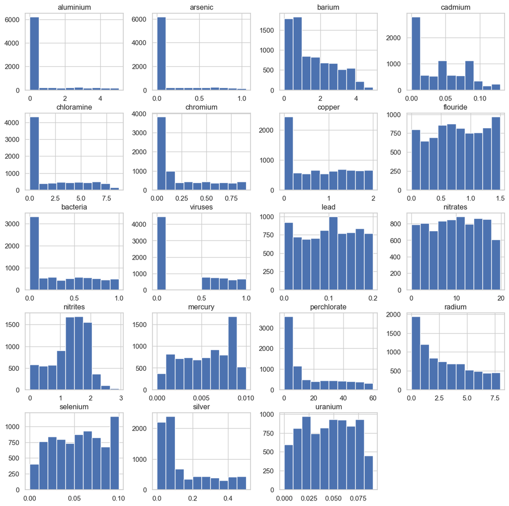

```python
#distribution data
df.hist(figsize=(14, 14))
plt.show()
```

Kode diatas bertujuan untuk memberikan visualisasi distribusi data dari dataframe df menggunakan histogram. Histogram adalah grafik yang membagi rentang data ke dalam interval dan menghitung jumlah data yang jatuh dalam setiap interval tersebut. Ini membantu untuk memahami pola distribusi data dan melihat sebaran nilai-nilai dalam dataset.

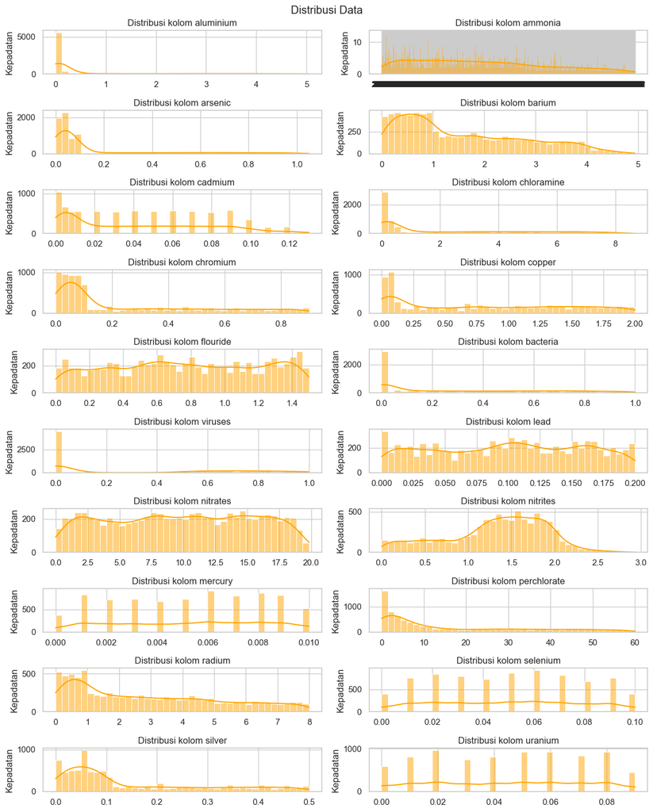

```python
sns.set(style='whitegrid')

# Plot histograms for the distribution of all columns
plt.figure(figsize=(12, 15))
data_columns = df.columns.tolist()
data_columns.remove('is_safe')

# Adjust the number of rows and columns in the subplot grid for better visualization
num_rows = len(data_columns) // 2 + len(data_columns) % 2
num_cols = 2

for i, column in enumerate(data_columns):
    plt.subplot(num_rows, num_cols, i + 1)
    sns.histplot(df[column], kde=True, color='orange', bins=40)
    plt.title(f'Distribusi kolom {column}', fontsize=12)
    plt.xlabel('')
    plt.ylabel('Kepadatan')

plt.suptitle("Distribusi Data")
plt.tight_layout()
plt.show()
```

Kode di atas mengatur gaya plot, kemudian memplot histogram untuk distribusi semua kolom pada DataFrame. Setiap subplot menunjukkan distribusi nilai dari satu kolom, dan garis halus (kernel density estimation) ditambahkan untuk memberikan representasi kepadatan distribusi data.

- ### Matrix Korelasi

Kode berikut dibawah ini menghasilkan sebuah matriks korelasi dengan menggunakan fungsi corr() dari pandas pada DataFrame df. Matriks korelasi ini merepresentasikan hubungan linier antara semua pasangan variabel dalam dataset. Setiap sel dalam matriks menunjukkan nilai korelasi antara dua variabel.

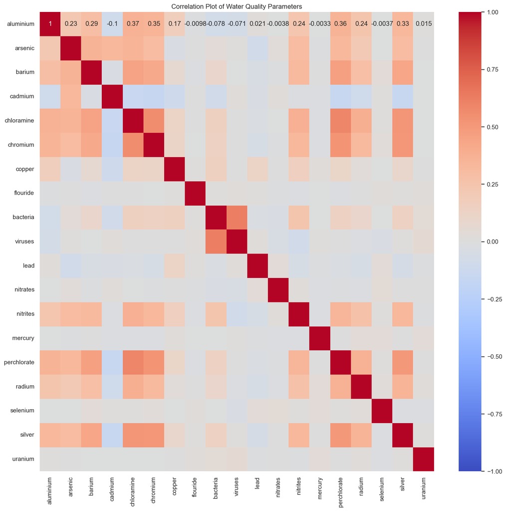

```python
correlation_matrix = df.corr()

plt.figure(figsize=(16, 15))
sns.heatmap(correlation_matrix, annot=True, cmap='coolwarm', center=0, vmin=-1, vmax=1)
plt.title("Correlation Plot of Water Quality Parameters")
plt.show()
```

Cara membaca matriks korelasi:

Skala Nilai Korelasi:

- 1.0: Korelasi sempurna positif. Artinya, jika satu variabel naik, yang lain juga naik secara linear.
- -1.0: Korelasi sempurna negatif. Artinya, jika satu variabel naik, yang lain turun secara linear.
- 0.0: Tidak ada korelasi linier antara variabel tersebut.

Warna Sel pada Heatmap digunakan untuk memvisualisasikan matriks korelasi. Sel-sel dengan warna yang lebih terang atau lebih gelap menunjukkan nilai korelasi yang lebih tinggi, sementara warna yang lebih netral menunjukkan korelasi yang lebih rendah.

- ### Diagram Lingkaran perbandingan jumlah data kelas

ini digunakan untuk menggambarkan persentasi perbandingan distribusi data setiap kelas yakni kelas 0 (tidak aman) dan kelas 1 (aman)

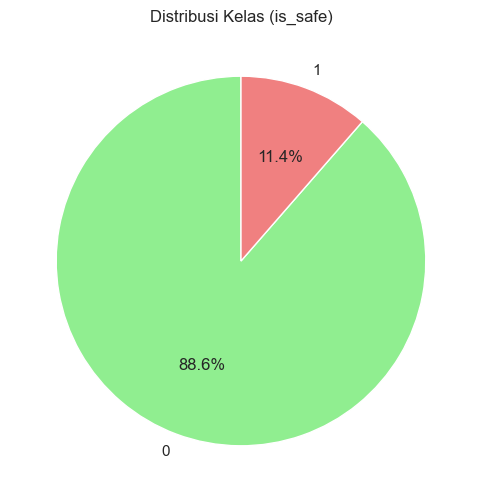

```python
import matplotlib.pyplot as plt

# Menghapus baris dengan nilai '#NUM!'
df_cleaned = df[df != '#NUM!'].dropna()

# Menghitung jumlah data untuk setiap kelas
class_counts = df_cleaned['is_safe'].value_counts()

# Membuat plot pie chart
plt.figure(figsize=(6, 6))
plt.pie(class_counts, labels=class_counts.index, autopct='%1.1f%%', startangle=90, colors=['lightgreen', 'lightcoral'])
plt.title('Distribusi Kelas (is_safe)')
plt.show()
```

# Pre-Procesing

Preprocessing (pra-pemrosesan) adalah tahap dalam analisis data yang bertujuan untuk membersihkan, mengorganisir, dan menyesuaikan data sehingga dapat digunakan secara efektif untuk pemodelan atau analisis lebih lanjut.

## Handling Missing Data

Mengidentifikasi dan menangani nilai-nilai yang hilang dalam dataset. Cara penanganannya bisa berupa menghapus baris/kolom yang mengandung nilai yang hilang atau mengisi nilai yang hilang dengan suatu nilai (misalnya, rata-rata, median, atau nilai yang paling sering muncul).

Sebelumnya telah teridentifikasi bahwa dataset water quality ini memiliki 3 nilai yang hilang atau berupa #NUM! pada kolom amonia dan is_safe, selain itu kolom tersebut yang masih berupa object bukan numeric. oleh karena itu perlu dilakukan penanganan dengan cara menghapus kolom yang memiliki nilai yang hilang tersebut.

```python
# Membaca data dari file csv
df = pd.read_csv('waterQuality1.csv')
```

Pertama kita ganti nilai #NUM! menjadi NaN. Fungsi replace() digunakan untuk mengganti sebuah nilai pada dataframe. Misalnya disini kita mengganti nilai #NUM! yang ada di dataframe dengan NaN.

```python
df.replace("#NUM!", pd.NA, inplace=True)
```

Selanjutnya menseleksi dataframe yang kolom amonia-nya tidak mengandung missing value atau NaN. artinya kolom yang hilang tadi dilakukan penghapusan data.

```python
df = df[df['ammonia'].notna()]
```

Lalu dilakukan penggantian tipe data kolom amonia dan is_safe yang sebelumnya berupa object atau string menjadi tipe data numeric menggunakan fungsi to_numeric().

```python
df['ammonia'] = pd.to_numeric(df['ammonia'])
df['is_safe'] = pd.to_numeric(df['is_safe'])
```

selanjutnya dilakukan pengecekan kembali terhadap dataset apakah missing value telah dihapus atau belum, dan melihat tipe data dari setiap kolomnya apakah sudah menjadi numeric semua.

```python
# Menghitung apakah ada nilai yang hilang dalam setiap kolom
missing_values = df.isna().any()

# Menampilkan hasil
print("Apakah ada nilai yang hilang dalam setiap kolom:")
print(missing_values)

nan_kolom = df.isna().sum()
print("Jumlah nilai yang hilang (NA) untuk setiap kolom:")
print(nan_kolom)
```

```
Apakah ada nilai yang hilang dalam setiap kolom:
aluminium      False
ammonia        False
arsenic        False
barium         False
cadmium        False
chloramine     False
chromium       False
copper         False
flouride       False
bacteria       False
viruses        False
lead           False
nitrates       False
nitrites       False
mercury        False
perchlorate    False
radium         False
selenium       False
silver         False
uranium        False
is_safe        False
dtype: bool
Jumlah nilai yang hilang (NA) untuk setiap kolom:
aluminium      0
ammonia        0
arsenic        0
barium         0
cadmium        0
chloramine     0
chromium       0
copper         0
flouride       0
bacteria       0
viruses        0
lead           0
nitrates       0
nitrites       0
mercury        0
perchlorate    0
radium         0
selenium       0
silver         0
uranium        0
is_safe        0
dtype: int64
```

```python
df.info()
```

```
<class 'pandas.core.frame.DataFrame'>
Int64Index: 7996 entries, 0 to 7998
Data columns (total 21 columns):
 #   Column       Non-Null Count  Dtype
---  ------       --------------  -----
 0   aluminium    7996 non-null   float64
 1   ammonia      7996 non-null   float64
 2   arsenic      7996 non-null   float64
 3   barium       7996 non-null   float64
 4   cadmium      7996 non-null   float64
 5   chloramine   7996 non-null   float64
 6   chromium     7996 non-null   float64
 7   copper       7996 non-null   float64
 8   flouride     7996 non-null   float64
 9   bacteria     7996 non-null   float64
 10  viruses      7996 non-null   float64
 11  lead         7996 non-null   float64
 12  nitrates     7996 non-null   float64
 13  nitrites     7996 non-null   float64
 14  mercury      7996 non-null   float64
 15  perchlorate  7996 non-null   float64
 16  radium       7996 non-null   float64
 17  selenium     7996 non-null   float64
 18  silver       7996 non-null   float64
 19  uranium      7996 non-null   float64
 20  is_safe      7996 non-null   int64
dtypes: float64(20), int64(1)
memory usage: 1.3 MB
```

Melalui pengecekan ini, didapati bahwa missing value telah dihapus, dan tipe data kolom sudah menjadi numeric dan bukan object. Selanjutnya kita bisa simpang hasil data yang sudah tidak ada missing value dengan nama datanomissing.csv

```python
df.to_csv('datanomissing.csv', index=False)
```

## Data Cleaning

Data cleaning kali ini akan Mendeteksi dan mengatasi noise atau outlier dalam data. Noise dapat muncul sebagai nilai yang ekstrim atau tidak sesuai dengan distribusi umum data. Dalam data cleaning ini saya akan menggunakan metode Local Outlier Factor. Didapati pada data understanding dimana outlier terdeteksi sebanyak 1999 data dan perlu dilakukan penghapusan data tersebut.

```python
# Membaca data dari file csv
df = pd.read_csv('datanomissing.csv')
```

Kita coba gambarkan data dan sebarannya melalui BoxPlot untuk mengetahui seperti apa data outlier dalam setiap kolom.

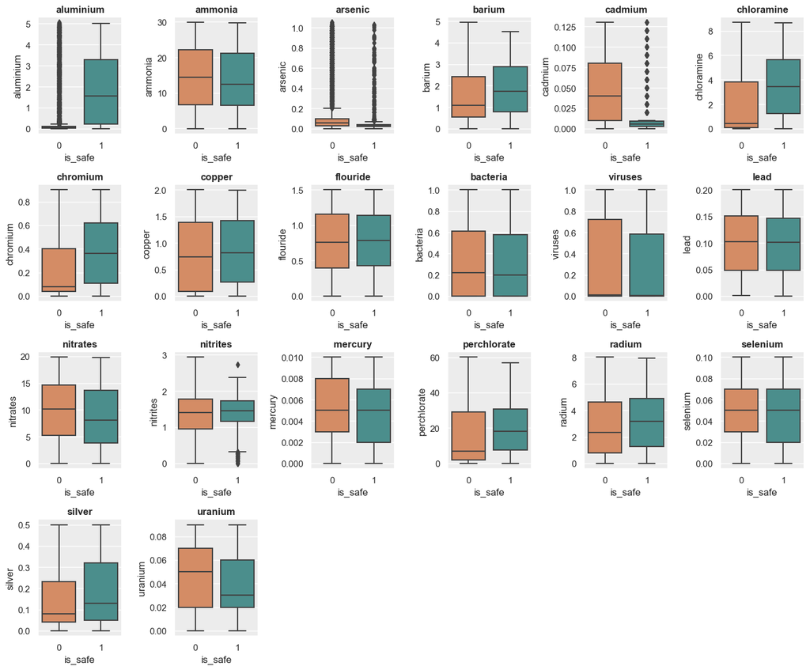

```python
# Create a list of numerical features and plot them
list_of_num_features = df.drop(columns=['is_safe'])  # DataFrame of numerical features
palette_features = ['#E68753', '#409996']
sns.set(rc={'axes.facecolor':'#ECECEC'})

# Mengatur tata letak subplot
num_rows = 5
num_cols = 6
fig, axes = plt.subplots(num_rows, num_cols, figsize=(14, 14), sharex=False, sharey=False)

# Flatten array of subplots for ease of indexing
axes = axes.flatten()

for idx, feature in enumerate(list_of_num_features.columns):
    ax = axes[idx]  # Mengambil subplot yang sesuai
    sns.boxplot(x='is_safe', y=feature, data=df, palette=palette_features, ax=ax)
    ax.set_title(feature, fontsize=12, fontweight='bold', ha='center')

# Sembunyikan subplot yang tidak digunakan
for i in range(len(list_of_num_features.columns), num_rows * num_cols):
    fig.delaxes(axes[i])

# Atur tata letak dan tampilkan plot
plt.tight_layout()
plt.show()
```

Kita coba kembali menggunakan local outlier factor untuk mendeteksi jumlah data outlier di dalam data menggunakan fungsi LocalOutlierFactor dengan parameter n_neigbors yakni 1 dan contamination yakni 0,25. Parameter ini didapat dari pencarian menggunakan grid search pada data undestanding di atas. Selanjutnya baris data yang terdeteksi sebagai outlier akan diberikan label -1 sedangkan yang bukan outlier akan diberi label 1

```python
# Menggunakan Local Outlier Factor
lof = LocalOutlierFactor(n_neighbors=1, contamination=0.25)
outlier_labels = lof.fit_predict(df)
df['Outlier'] = outlier_labels
df
```

|  | aluminium | ammonia | arsenic | barium | cadmium | chloramine | chromium | copper | flouride | bacteria | ... | nitrates | nitrites | mercury | perchlorate | radium | selenium | silver | uranium | is_safe | Outlier |
| --- | --- | --- | --- | --- | --- | --- | --- | --- | --- | --- | --- | --- | --- | --- | --- | --- | --- | --- | --- | --- | --- |
| 0 | 1.65 | 9.08 | 0.04 | 2.85 | 0.007 | 0.35 | 0.83 | 0.17 | 0.05 | 0.20 | ... | 16.08 | 1.13 | 0.007 | 37.75 | 6.78 | 0.08 | 0.34 | 0.02 | 1 | 1 |
| 1 | 2.32 | 21.16 | 0.01 | 3.31 | 0.002 | 5.28 | 0.68 | 0.66 | 0.90 | 0.65 | ... | 2.01 | 1.93 | 0.003 | 32.26 | 3.21 | 0.08 | 0.27 | 0.05 | 1 | 1 |
| 2 | 1.01 | 14.02 | 0.04 | 0.58 | 0.008 | 4.24 | 0.53 | 0.02 | 0.99 | 0.05 | ... | 14.16 | 1.11 | 0.006 | 50.28 | 7.07 | 0.07 | 0.44 | 0.01 | 0 | 1 |
| 3 | 1.36 | 11.33 | 0.04 | 2.96 | 0.001 | 7.23 | 0.03 | 1.66 | 1.08 | 0.71 | ... | 1.41 | 1.29 | 0.004 | 9.12 | 1.72 | 0.02 | 0.45 | 0.05 | 1 | 1 |
| 4 | 0.92 | 24.33 | 0.03 | 0.20 | 0.006 | 2.67 | 0.69 | 0.57 | 0.61 | 0.13 | ... | 6.74 | 1.11 | 0.003 | 16.90 | 2.41 | 0.02 | 0.06 | 0.02 | 1 | 1 |
| ... | ... | ... | ... | ... | ... | ... | ... | ... | ... | ... | ... | ... | ... | ... | ... | ... | ... | ... | ... | ... | ... |
| 7991 | 0.05 | 7.78 | 0.00 | 1.95 | 0.040 | 0.10 | 0.03 | 0.03 | 1.37 | 0.00 | ... | 14.29 | 1.00 | 0.005 | 3.57 | 2.13 | 0.09 | 0.06 | 0.03 | 1 | 1 |
| 7992 | 0.05 | 24.22 | 0.02 | 0.59 | 0.010 | 0.45 | 0.02 | 0.02 | 1.48 | 0.00 | ... | 10.27 | 1.00 | 0.001 | 1.48 | 1.11 | 0.09 | 0.10 | 0.08 | 1 | -1 |
| 7993 | 0.09 | 6.85 | 0.00 | 0.61 | 0.030 | 0.05 | 0.05 | 0.02 | 0.91 | 0.00 | ... | 15.92 | 1.00 | 0.000 | 1.35 | 4.84 | 0.00 | 0.04 | 0.05 | 1 | 1 |
| 7994 | 0.01 | 10.00 | 0.01 | 2.00 | 0.000 | 2.00 | 0.00 | 0.09 | 0.00 | 0.00 | ... | 0.00 | 0.00 | 0.000 | 0.00 | 0.00 | 0.00 | 0.00 | 0.00 | 1 | -1 |
| 7995 | 0.04 | 6.85 | 0.01 | 0.70 | 0.030 | 0.05 | 0.01 | 0.03 | 1.00 | 0.00 | ... | 15.92 | 1.00 | 0.000 | 1.35 | 4.84 | 0.00 | 0.04 | 0.05 | 1 | 1 |

7996 rows × 22 columns

Selanjutnya menghitung jumlah outlier di dalam dataset water quality atau data yang memiliki label -1, dan menemukan sebanyak 1999 data termasuk data outlier.

```python
# Menghitung jumlah outlier
total_outliers = (df['Outlier'] == -1).sum()
print("Total Jumlah Outlier:", total_outliers)

# Menghitung jumlah outlier
total_no_outliers = (df['Outlier'] == 1).sum()
print("Total Data Tanpa Outlier:", total_no_outliers)
```

```
Total Jumlah Outlier: 1999
Total Data Tanpa Outlier: 5997
```

```python
df_no_outliers = df[df['Outlier'] != -1]
df_no_outliers = df_no_outliers.drop(columns=['Outlier'])
df_no_outliers.to_csv('data_no_outliers.csv', index=False)

df = pd.read_csv('data_no_outliers.csv')
# Menghitung jumlah target pada data tanpa outlier
classnooutlier = df['is_safe'].value_counts()

print("Jumlah target pada data tanpa outlier:")
print(classnooutlier)
```

```
Jumlah target pada data tanpa outlier:
0    5236
1     761
Name: is_safe, dtype: int64
```

## Handling Imbalanced Data

Balancing kelas pada dataset ini menggunakan teknik Random Over-Sampling With imblearn. Random Over-Sampling With imblearn adalah salah satu teknik yang digunakan untuk menangani ketidakseimbangan kelas. Dalam metode ini, jumlah sampel dalam kelas minoritas ditingkatkan dengan menambahkan salinan acak dari sampel yang sudah ada dalam kelas tersebut. Metode Random Over-Sampling memungkinkan untuk mengatasi ketidakseimbangan kelas tanpa menghapus data dari kelas mayoritas, sehingga tidak ada informasi yang hilang dalam prosesnya.

```python
df = pd.read_csv('data_no_outliers.csv')
```

### Perbandingan kelas data awal

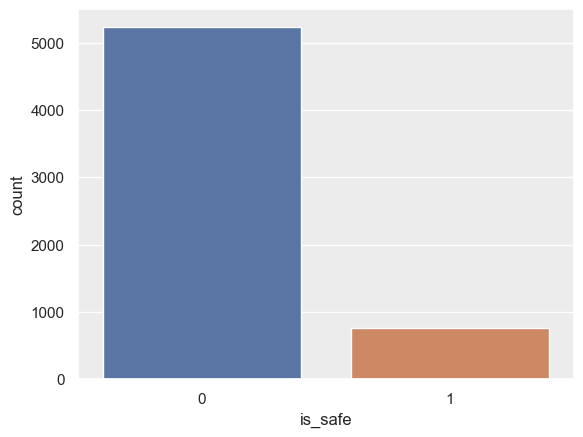

```
class 0 (Not Safe) : (5236, 21)
class 1 (Safe)     : (761, 21)
```

```python
sns.countplot(data = df, x = 'is_safe')
plt.show()
# sebaran class
class_0 = df[df['is_safe'] == 0]
class_1 = df[df['is_safe'] == 1]
print('class 0 (Not Safe) :', class_0.shape)
print('class 1 (Safe)     :', class_1.shape)
```

### Proses Balancing Data

Proses Random Over Sampling adalah sebagai berikut:

[figure not shown]

- Identifikasi Kelas Minoritas dengan menentukan kelas yang memiliki jumlah sampel lebih sedikit dan dianggap sebagai kelas minoritas.
- Hitung selisih antara jumlah sampel di kelas mayoritas dan kelas minoritas.
- Pilih Sampel Acak Dari kelas minoritas, pilih sampel secara acak sebanyak selisih yang dihitung.
- Duplikasi sampel acak yang telah dipilih dan tambahkan ke dataset. Dengan kata lain, kita menambahkan kembali sampel-sampel ini ke kelas minoritas.

```
Sebaran Data :
Sebaran Data Kelas Awal: Counter({0: 5236, 1: 761})
Sebaran Data Kelas Setelah Balancing: Counter({1: 5236, 0: 5236})

Jumlah keseluruhan data setelah balancing sampling :
Features (X_ros) shape: (10472, 20)
Target (y_ros) shape: (10472,)
```

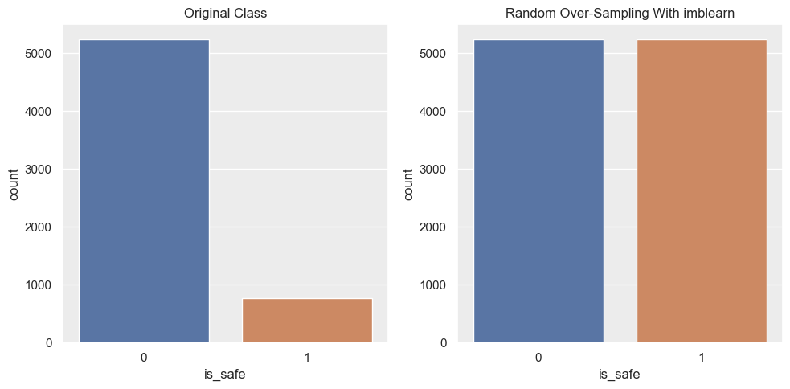

```python
# Separate features (X) and target variable (y)
X = df.drop('is_safe', axis=1)
y = df['is_safe']

# Print original class distribution
print('Sebaran Data :')
print('Sebaran Data Kelas Awal:', Counter(y))

# Initialize RandomOverSampler
ros = RandomOverSampler(random_state=42)

# Apply Random Over-Sampling to balance the classes
X_ros, y_ros = ros.fit_resample(X, y)

# Print resampled class distribution
print('Sebaran Data Kelas Setelah Balancing:', Counter(y_ros))

# Menampilkan jumlah data setelah balancing sampling
print('\nJumlah keseluruhan data setelah balancing sampling :')
print('Features (X_ros) shape:', X_ros.shape)
print('Target (y_ros) shape:', y_ros.shape)

#visualisasi perbandingan data kelas
# Plot original class distribution
plt.figure(figsize=(10, 5))
plt.subplot(1, 2, 1)
sns.countplot(data=df, x='is_safe')
plt.title('Original Class')

# Plot resampled class distribution after Random Over-Sampling
plt.subplot(1, 2, 2)
sns.countplot(data=pd.DataFrame({'is_safe': y_ros}), x='is_safe')
plt.title('Random Over-Sampling With imblearn')

plt.tight_layout()
plt.show()
```

```python
# Mengonversi array NumPy ke DataFrame pandas
df_X_ros = pd.DataFrame(X_ros, columns=X.columns)
df_y_ros = pd.DataFrame(y_ros, columns=['is_safe'])
# Menggabungkan DataFrame X_ros dan y_ros
df_resampled = pd.concat([df_X_ros, df_y_ros], axis=1)

# Menyimpan DataFrame ke dalam file Excel
df_resampled.to_csv('data_balancing.csv', index=False)
df_resampled
```

|  | aluminium | ammonia | arsenic | barium | cadmium | chloramine | chromium | copper | flouride | bacteria | ... | lead | nitrates | nitrites | mercury | perchlorate | radium | selenium | silver | uranium | is_safe |
| --- | --- | --- | --- | --- | --- | --- | --- | --- | --- | --- | --- | --- | --- | --- | --- | --- | --- | --- | --- | --- | --- |
| 0 | 1.65 | 9.08 | 0.04 | 2.85 | 0.007 | 0.35 | 0.83 | 0.17 | 0.05 | 0.20 | ... | 0.054 | 16.08 | 1.13 | 0.007 | 37.75 | 6.78 | 0.08 | 0.34 | 0.02 | 1 |
| 1 | 2.32 | 21.16 | 0.01 | 3.31 | 0.002 | 5.28 | 0.68 | 0.66 | 0.90 | 0.65 | ... | 0.100 | 2.01 | 1.93 | 0.003 | 32.26 | 3.21 | 0.08 | 0.27 | 0.05 | 1 |
| 2 | 1.01 | 14.02 | 0.04 | 0.58 | 0.008 | 4.24 | 0.53 | 0.02 | 0.99 | 0.05 | ... | 0.078 | 14.16 | 1.11 | 0.006 | 50.28 | 7.07 | 0.07 | 0.44 | 0.01 | 0 |
| 3 | 1.36 | 11.33 | 0.04 | 2.96 | 0.001 | 7.23 | 0.03 | 1.66 | 1.08 | 0.71 | ... | 0.016 | 1.41 | 1.29 | 0.004 | 9.12 | 1.72 | 0.02 | 0.45 | 0.05 | 1 |
| 4 | 0.92 | 24.33 | 0.03 | 0.20 | 0.006 | 2.67 | 0.69 | 0.57 | 0.61 | 0.13 | ... | 0.117 | 6.74 | 1.11 | 0.003 | 16.90 | 2.41 | 0.02 | 0.06 | 0.02 | 1 |
| ... | ... | ... | ... | ... | ... | ... | ... | ... | ... | ... | ... | ... | ... | ... | ... | ... | ... | ... | ... | ... | ... |
| 10467 | 1.55 | 11.30 | 0.02 | 3.14 | 0.007 | 7.52 | 0.03 | 0.10 | 1.38 | 0.00 | ... | 0.033 | 7.43 | 1.55 | 0.007 | 19.77 | 2.42 | 0.09 | 0.26 | 0.02 | 1 |
| 10468 | 0.05 | 29.28 | 0.06 | 0.40 | 0.030 | 0.07 | 0.02 | 1.05 | 0.81 | 0.00 | ... | 0.066 | 4.62 | 0.90 | 0.000 | 2.08 | 1.80 | 0.07 | 0.09 | 0.02 | 1 |
| 10469 | 0.39 | 28.28 | 0.44 | 1.74 | 0.120 | 5.14 | 0.05 | 0.03 | 1.29 | 0.43 | ... | 0.108 | 9.90 | 1.86 | 0.004 | 29.06 | 2.12 | 0.07 | 0.07 | 0.01 | 1 |
| 10470 | 3.12 | 18.12 | 0.03 | 3.98 | 0.006 | 1.87 | 0.07 | 0.66 | 0.04 | 0.32 | ... | 0.028 | 8.02 | 1.07 | 0.002 | 40.27 | 1.16 | 0.00 | 0.35 | 0.02 | 1 |
| 10471 | 1.14 | 17.45 | 0.35 | 1.32 | 0.040 | 1.45 | 0.38 | 0.41 | 0.72 | 0.00 | ... | 0.020 | 1.27 | 1.55 | 0.010 | 45.06 | 2.97 | 0.06 | 0.10 | 0.02 | 1 |

10472 rows × 21 columns

## Feature Scaling

Metode Normalisasi Robust Scaler adalah salah satu teknik normalisasi data yang tahan terhadap outlier.  
Robust Scaler mengubah setiap nilai dalam suatu fitur dengan menggunakan rumus berikut: \begin{equation} X_{\text{scaled}} = \frac{{X - \text{median}}}{{Q_3 - Q_1}} \end{equation} Dimana :

- Xscaled : adalah nilai yang telah diubah skala,
- X : adalah nilai asli,
- Q1 : adalah kuartil pertama (25th percentile),
- Q3 : adalah kuartil ketiga (75th percentile),
- Median : Nilai Tengah.

Berikut adalah proses normalisasi menggunakan Robust Scaler dan contoh kasusnya:

Proses Normalisasi menggunakan Robust Scaler:

1. Hitung Median dan Kuartil:
   - Median (Q2): Nilai tengah dari set data.
   - Kuartil 1 (Q1): Nilai tengah antara nilai terkecil dan median.
   - Kuartil 3 (Q3): Nilai tengah antara median dan nilai terbesar.
2. Hitung Rentang Interkuartil (IQR):
   - IQR = Q3 - Q1.
3. Hitung Skala Robust:
   - Skala Robust = (X - Median) / IQR. Contoh Kasus: Misalkan kita memiliki dataset sebagai berikut:

[10, 15, 20, 25, 30, 100]

- Metode Robust Scaler ini memiliki keuntungan:
  - Tahan terhadap outlier: Robust Scaler lebih tahan terhadap outlier karena menggunakan informasi dari kuartil, yang kurang dipengaruhi oleh nilai ekstrem.
  - Konservatif: Dengan menggunakan median dan IQR, metode ini dapat menghasilkan normalisasi yang lebih konservatif daripada Min-Max Scaling.
- Metode Robust Scaler Cocok Digunakan Jika:
  - Data mengandung nilai ekstrem atau outlier.
  - Distribusi data tidak terdistribusi normal.
  - Skala fitur bervariasi secara signifikan.
- Perbandingan dengan Min-Max Scaling dan Z-Score Scaling:
  - Min-Max Scaling: Rentang nilai diubah menjadi 0 hingga 1. Rentang ini dapat sangat dipengaruhi oleh nilai outlier. Jika outlier signifikan, rentang nilai mungkin menjadi terlalu sempit.
  - Z-Score Scaling (Standardization): Data diubah sehingga memiliki rata-rata 0 dan deviasi standar 1. Metode ini sensitif terhadap nilai ekstrem dan tidak sebaik Robust Scaler ketika ada outlier.

```python
df = pd.read_csv('data_balancing.csv')
X = df.drop('is_safe', axis=1)
y = df['is_safe']
# Inisialisasi RobustScaler
RobustScaler = RobustScaler()

# Fit dan transformasi data menggunakan RobustScaler
df_scaled = RobustScaler.fit_transform(X)

# Membuat DataFrame baru dengan data yang telah diubah skala
X = pd.DataFrame(X, columns=X.columns)
y = pd.DataFrame(y, columns=['is_safe'])
datascled = pd.concat([X, y], axis=1)
df_normalized = pd.DataFrame(datascled)
df_normalized.to_csv('data_normalisasi.csv', index=False)

# Menampilkan hasil
print("Original Data:")
df
```

```
Original Data:
```

|  | aluminium | ammonia | arsenic | barium | cadmium | chloramine | chromium | copper | flouride | bacteria | ... | lead | nitrates | nitrites | mercury | perchlorate | radium | selenium | silver | uranium | is_safe |
| --- | --- | --- | --- | --- | --- | --- | --- | --- | --- | --- | --- | --- | --- | --- | --- | --- | --- | --- | --- | --- | --- |
| 0 | 1.65 | 9.08 | 0.04 | 2.85 | 0.007 | 0.35 | 0.83 | 0.17 | 0.05 | 0.20 | ... | 0.054 | 16.08 | 1.13 | 0.007 | 37.75 | 6.78 | 0.08 | 0.34 | 0.02 | 1 |
| 1 | 2.32 | 21.16 | 0.01 | 3.31 | 0.002 | 5.28 | 0.68 | 0.66 | 0.90 | 0.65 | ... | 0.100 | 2.01 | 1.93 | 0.003 | 32.26 | 3.21 | 0.08 | 0.27 | 0.05 | 1 |
| 2 | 1.01 | 14.02 | 0.04 | 0.58 | 0.008 | 4.24 | 0.53 | 0.02 | 0.99 | 0.05 | ... | 0.078 | 14.16 | 1.11 | 0.006 | 50.28 | 7.07 | 0.07 | 0.44 | 0.01 | 0 |
| 3 | 1.36 | 11.33 | 0.04 | 2.96 | 0.001 | 7.23 | 0.03 | 1.66 | 1.08 | 0.71 | ... | 0.016 | 1.41 | 1.29 | 0.004 | 9.12 | 1.72 | 0.02 | 0.45 | 0.05 | 1 |
| 4 | 0.92 | 24.33 | 0.03 | 0.20 | 0.006 | 2.67 | 0.69 | 0.57 | 0.61 | 0.13 | ... | 0.117 | 6.74 | 1.11 | 0.003 | 16.90 | 2.41 | 0.02 | 0.06 | 0.02 | 1 |
| ... | ... | ... | ... | ... | ... | ... | ... | ... | ... | ... | ... | ... | ... | ... | ... | ... | ... | ... | ... | ... | ... |
| 10467 | 1.55 | 11.30 | 0.02 | 3.14 | 0.007 | 7.52 | 0.03 | 0.10 | 1.38 | 0.00 | ... | 0.033 | 7.43 | 1.55 | 0.007 | 19.77 | 2.42 | 0.09 | 0.26 | 0.02 | 1 |
| 10468 | 0.05 | 29.28 | 0.06 | 0.40 | 0.030 | 0.07 | 0.02 | 1.05 | 0.81 | 0.00 | ... | 0.066 | 4.62 | 0.90 | 0.000 | 2.08 | 1.80 | 0.07 | 0.09 | 0.02 | 1 |
| 10469 | 0.39 | 28.28 | 0.44 | 1.74 | 0.120 | 5.14 | 0.05 | 0.03 | 1.29 | 0.43 | ... | 0.108 | 9.90 | 1.86 | 0.004 | 29.06 | 2.12 | 0.07 | 0.07 | 0.01 | 1 |
| 10470 | 3.12 | 18.12 | 0.03 | 3.98 | 0.006 | 1.87 | 0.07 | 0.66 | 0.04 | 0.32 | ... | 0.028 | 8.02 | 1.07 | 0.002 | 40.27 | 1.16 | 0.00 | 0.35 | 0.02 | 1 |
| 10471 | 1.14 | 17.45 | 0.35 | 1.32 | 0.040 | 1.45 | 0.38 | 0.41 | 0.72 | 0.00 | ... | 0.020 | 1.27 | 1.55 | 0.010 | 45.06 | 2.97 | 0.06 | 0.10 | 0.02 | 1 |

10472 rows × 21 columns

```python
print("\nNormalized Data (Robust Scaling):")
df_normalized
```

```
Normalized Data (Robust Scaling):
```

|  | aluminium | ammonia | arsenic | barium | cadmium | chloramine | chromium | copper | flouride | bacteria | ... | lead | nitrates | nitrites | mercury | perchlorate | radium | selenium | silver | uranium | is_safe |
| --- | --- | --- | --- | --- | --- | --- | --- | --- | --- | --- | --- | --- | --- | --- | --- | --- | --- | --- | --- | --- | --- |
| 0 | 1.65 | 9.08 | 0.04 | 2.85 | 0.007 | 0.35 | 0.83 | 0.17 | 0.05 | 0.20 | ... | 0.054 | 16.08 | 1.13 | 0.007 | 37.75 | 6.78 | 0.08 | 0.34 | 0.02 | 1 |
| 1 | 2.32 | 21.16 | 0.01 | 3.31 | 0.002 | 5.28 | 0.68 | 0.66 | 0.90 | 0.65 | ... | 0.100 | 2.01 | 1.93 | 0.003 | 32.26 | 3.21 | 0.08 | 0.27 | 0.05 | 1 |
| 2 | 1.01 | 14.02 | 0.04 | 0.58 | 0.008 | 4.24 | 0.53 | 0.02 | 0.99 | 0.05 | ... | 0.078 | 14.16 | 1.11 | 0.006 | 50.28 | 7.07 | 0.07 | 0.44 | 0.01 | 0 |
| 3 | 1.36 | 11.33 | 0.04 | 2.96 | 0.001 | 7.23 | 0.03 | 1.66 | 1.08 | 0.71 | ... | 0.016 | 1.41 | 1.29 | 0.004 | 9.12 | 1.72 | 0.02 | 0.45 | 0.05 | 1 |
| 4 | 0.92 | 24.33 | 0.03 | 0.20 | 0.006 | 2.67 | 0.69 | 0.57 | 0.61 | 0.13 | ... | 0.117 | 6.74 | 1.11 | 0.003 | 16.90 | 2.41 | 0.02 | 0.06 | 0.02 | 1 |
| ... | ... | ... | ... | ... | ... | ... | ... | ... | ... | ... | ... | ... | ... | ... | ... | ... | ... | ... | ... | ... | ... |
| 10467 | 1.55 | 11.30 | 0.02 | 3.14 | 0.007 | 7.52 | 0.03 | 0.10 | 1.38 | 0.00 | ... | 0.033 | 7.43 | 1.55 | 0.007 | 19.77 | 2.42 | 0.09 | 0.26 | 0.02 | 1 |
| 10468 | 0.05 | 29.28 | 0.06 | 0.40 | 0.030 | 0.07 | 0.02 | 1.05 | 0.81 | 0.00 | ... | 0.066 | 4.62 | 0.90 | 0.000 | 2.08 | 1.80 | 0.07 | 0.09 | 0.02 | 1 |
| 10469 | 0.39 | 28.28 | 0.44 | 1.74 | 0.120 | 5.14 | 0.05 | 0.03 | 1.29 | 0.43 | ... | 0.108 | 9.90 | 1.86 | 0.004 | 29.06 | 2.12 | 0.07 | 0.07 | 0.01 | 1 |
| 10470 | 3.12 | 18.12 | 0.03 | 3.98 | 0.006 | 1.87 | 0.07 | 0.66 | 0.04 | 0.32 | ... | 0.028 | 8.02 | 1.07 | 0.002 | 40.27 | 1.16 | 0.00 | 0.35 | 0.02 | 1 |
| 10471 | 1.14 | 17.45 | 0.35 | 1.32 | 0.040 | 1.45 | 0.38 | 0.41 | 0.72 | 0.00 | ... | 0.020 | 1.27 | 1.55 | 0.010 | 45.06 | 2.97 | 0.06 | 0.10 | 0.02 | 1 |

10472 rows × 21 columns

## Splitting Data

Memisahkan dataset menjadi set pelatihan dan set pengujian untuk evaluasi model.

```python
df = pd.read_csv('data_normalisasi.csv')
```

```python
X = df.drop('is_safe', axis=1)
y = df['is_safe']
X_train, X_test, y_train, y_test = train_test_split(X, y, test_size=0.2, random_state=42)
```

## Pycaret Seleksi Model

PyCaret adalah sebuah perpustakaan (library) Python yang dirancang untuk memudahkan proses pengembangan model dan eksperimen machine learning. PyCaret menyederhanakan tugas-tugas seperti pemrosesan data, pemilihan model, penyetelan parameter (hyperparameter tuning), evaluasi model, dan penerapan model ke dalam produksi. Tujuannya adalah untuk mempercepat siklus pengembangan model dan membuatnya lebih mudah diakses bagi orang yang mungkin belum memiliki keahlian mendalam dalam machine learning.

Berikut adalah beberapa fitur utama dari PyCaret:

1. PyCaret menyediakan fungsi setup yang otomatis menangani berbagai tugas pra-pemrosesan data seperti penanganan nilai-nilai yang hilang, pengkodean variabel kategorikal, pemilihan fitur, dan lainnya.
2. PyCaret memungkinkan pengguna untuk mengevaluasi beberapa model machine learning secara bersamaan dan memilih model terbaik berdasarkan kinerja menggunakan Fungsi compare_models.
3. PyCaret mendukung penyetelan otomatis parameter (hyperparameter tuning) untuk meningkatkan kinerja model dengan menggunakan Fungsi tune_model.
4. PyCaret menyediakan berbagai metrik evaluasi kinerja model dan visualisasi yang berguna. Seperti kurva ROC, distribusi prediksi, dan lainnya.
5. Setelah memilih model terbaik, PyCaret memudahkan proses penerapan model ke dalam produksi dengan fungsi finalize_model.

```python
from pycaret.regression import *
from pycaret.classification import *
```

```python
clf = setup(df, target='is_safe')
```

|  | Description | Value |
| --- | --- | --- |
| 0 | Session id | 1302 |
| 1 | Target | is_safe |
| 2 | Target type | Binary |
| 3 | Original data shape | (10472, 21) |
| 4 | Transformed data shape | (10472, 21) |
| 5 | Transformed train set shape | (7330, 21) |
| 6 | Transformed test set shape | (3142, 21) |
| 7 | Numeric features | 20 |
| 8 | Preprocess | True |
| 9 | Imputation type | simple |
| 10 | Numeric imputation | mean |
| 11 | Categorical imputation | mode |
| 12 | Fold Generator | StratifiedKFold |
| 13 | Fold Number | 10 |
| 14 | CPU Jobs | -1 |
| 15 | Use GPU | False |
| 16 | Log Experiment | False |
| 17 | Experiment Name | clf-default-name |
| 18 | USI | 477e |

Melalui pencarian model terbaik menggunakan fungsi compare_models() didapat 5 model klasifikasi terbaik dengan nilai akurasi tertinggi pada klasifikasi water quality, yakni :

```python
best = clf.compare_models()
```

|  | Model | Accuracy | AUC | Recall | Prec. | F1 | Kappa | MCC | TT (Sec) |
| --- | --- | --- | --- | --- | --- | --- | --- | --- | --- |
| lightgbm | Light Gradient Boosting Machine | 0.9842 | 0.9988 | 0.9989 | 0.9704 | 0.9844 | 0.9683 | 0.9688 | 0.3930 |
| rf | Random Forest Classifier | 0.9834 | 0.9996 | 0.9978 | 0.9699 | 0.9836 | 0.9667 | 0.9672 | 2.3300 |
| et | Extra Trees Classifier | 0.9834 | 0.9992 | 0.9932 | 0.9741 | 0.9835 | 0.9667 | 0.9669 | 1.0980 |
| dt | Decision Tree Classifier | 0.9805 | 0.9805 | 0.9973 | 0.9650 | 0.9808 | 0.9610 | 0.9616 | 0.1310 |
| gbc | Gradient Boosting Classifier | 0.9516 | 0.9901 | 0.9724 | 0.9337 | 0.9526 | 0.9031 | 0.9041 | 2.9780 |
| ada | Ada Boost Classifier | 0.8825 | 0.9542 | 0.8720 | 0.8911 | 0.8812 | 0.7651 | 0.7657 | 0.6700 |
| knn | K Neighbors Classifier | 0.8353 | 0.9012 | 0.9452 | 0.7751 | 0.8516 | 0.6707 | 0.6877 | 0.3000 |
| qda | Quadratic Discriminant Analysis | 0.8241 | 0.9027 | 0.8597 | 0.8028 | 0.8302 | 0.6483 | 0.6502 | 0.0700 |
| lda | Linear Discriminant Analysis | 0.7963 | 0.8676 | 0.7883 | 0.8013 | 0.7946 | 0.5926 | 0.5928 | 0.0670 |
| ridge | Ridge Classifier | 0.7930 | 0.0000 | 0.7784 | 0.8020 | 0.7900 | 0.5861 | 0.5864 | 0.0570 |
| lr | Logistic Regression | 0.7846 | 0.8635 | 0.7482 | 0.8073 | 0.7764 | 0.5692 | 0.5709 | 3.0300 |
| nb | Naive Bayes | 0.7836 | 0.8314 | 0.8183 | 0.7655 | 0.7909 | 0.5673 | 0.5688 | 0.0570 |
| svm | SVM - Linear Kernel | 0.6959 | 0.0000 | 0.7938 | 0.7110 | 0.7192 | 0.3920 | 0.4421 | 0.1580 |
| dummy | Dummy Classifier | 0.4993 | 0.5000 | 0.5000 | 0.2497 | 0.3330 | 0.0000 | 0.0000 | 0.0530 |

### Light Gradient Boosting Machine

```python
lightgbm = create_model('lightgbm')
```

| Fold | Accuracy | AUC | Recall | Prec. | F1 | Kappa | MCC |
| --- | --- | --- | --- | --- | --- | --- | --- |
| 0 | 0.9823 | 0.9969 | 0.9946 | 0.9707 | 0.9825 | 0.9645 | 0.9648 |
| 1 | 0.9864 | 0.9997 | 1.0000 | 0.9735 | 0.9866 | 0.9727 | 0.9731 |
| 2 | 0.9782 | 0.9994 | 0.9973 | 0.9606 | 0.9786 | 0.9563 | 0.9570 |
| 3 | 0.9809 | 0.9991 | 1.0000 | 0.9633 | 0.9813 | 0.9618 | 0.9625 |
| 4 | 0.9836 | 0.9964 | 1.0000 | 0.9683 | 0.9839 | 0.9673 | 0.9678 |
| 5 | 0.9932 | 1.0000 | 1.0000 | 0.9865 | 0.9932 | 0.9864 | 0.9864 |
| 6 | 0.9877 | 0.9998 | 1.0000 | 0.9760 | 0.9879 | 0.9754 | 0.9757 |
| 7 | 0.9905 | 0.9999 | 0.9973 | 0.9838 | 0.9905 | 0.9809 | 0.9810 |
| 8 | 0.9795 | 0.9979 | 1.0000 | 0.9606 | 0.9799 | 0.9591 | 0.9599 |
| 9 | 0.9795 | 0.9989 | 1.0000 | 0.9606 | 0.9799 | 0.9591 | 0.9599 |
| Mean | 0.9842 | 0.9988 | 0.9989 | 0.9704 | 0.9844 | 0.9683 | 0.9688 |
| Std | 0.0048 | 0.0012 | 0.0018 | 0.0091 | 0.0047 | 0.0096 | 0.0094 |

### Gradient Boosting Classifier

```python
gbc = create_model('gbc')
```

| Fold | Accuracy | AUC | Recall | Prec. | F1 | Kappa | MCC |
| --- | --- | --- | --- | --- | --- | --- | --- |
| 0 | 0.9509 | 0.9903 | 0.9728 | 0.9321 | 0.9520 | 0.9018 | 0.9026 |
| 1 | 0.9523 | 0.9932 | 0.9646 | 0.9415 | 0.9529 | 0.9045 | 0.9048 |
| 2 | 0.9427 | 0.9904 | 0.9837 | 0.9093 | 0.9450 | 0.8854 | 0.8884 |
| 3 | 0.9468 | 0.9918 | 0.9755 | 0.9227 | 0.9483 | 0.8936 | 0.8951 |
| 4 | 0.9591 | 0.9861 | 0.9809 | 0.9399 | 0.9600 | 0.9181 | 0.9190 |
| 5 | 0.9577 | 0.9925 | 0.9699 | 0.9467 | 0.9582 | 0.9154 | 0.9157 |
| 6 | 0.9509 | 0.9916 | 0.9727 | 0.9319 | 0.9519 | 0.9018 | 0.9026 |
| 7 | 0.9686 | 0.9927 | 0.9809 | 0.9573 | 0.9690 | 0.9372 | 0.9375 |
| 8 | 0.9454 | 0.9875 | 0.9590 | 0.9335 | 0.9461 | 0.8909 | 0.8912 |
| 9 | 0.9413 | 0.9844 | 0.9645 | 0.9217 | 0.9426 | 0.8827 | 0.8836 |
| Mean | 0.9516 | 0.9901 | 0.9724 | 0.9337 | 0.9526 | 0.9031 | 0.9041 |
| Std | 0.0079 | 0.0029 | 0.0077 | 0.0130 | 0.0076 | 0.0159 | 0.0155 |

### Random Forest

```python
rf = create_model('rf')
```

| Fold | Accuracy | AUC | Recall | Prec. | F1 | Kappa | MCC |
| --- | --- | --- | --- | --- | --- | --- | --- |
| 0 | 0.9850 | 0.9992 | 0.9946 | 0.9759 | 0.9852 | 0.9700 | 0.9702 |
| 1 | 0.9891 | 0.9999 | 0.9973 | 0.9812 | 0.9892 | 0.9782 | 0.9783 |
| 2 | 0.9741 | 0.9994 | 0.9946 | 0.9555 | 0.9746 | 0.9482 | 0.9490 |
| 3 | 0.9836 | 0.9999 | 1.0000 | 0.9683 | 0.9839 | 0.9673 | 0.9678 |
| 4 | 0.9741 | 0.9991 | 0.9973 | 0.9531 | 0.9747 | 0.9482 | 0.9492 |
| 5 | 0.9877 | 0.9998 | 1.0000 | 0.9760 | 0.9879 | 0.9754 | 0.9757 |
| 6 | 0.9795 | 1.0000 | 1.0000 | 0.9606 | 0.9799 | 0.9591 | 0.9599 |
| 7 | 0.9905 | 0.9999 | 0.9973 | 0.9838 | 0.9905 | 0.9809 | 0.9810 |
| 8 | 0.9850 | 0.9995 | 1.0000 | 0.9708 | 0.9852 | 0.9700 | 0.9704 |
| 9 | 0.9850 | 0.9994 | 0.9973 | 0.9733 | 0.9852 | 0.9700 | 0.9703 |
| Mean | 0.9834 | 0.9996 | 0.9978 | 0.9699 | 0.9836 | 0.9667 | 0.9672 |
| Std | 0.0055 | 0.0003 | 0.0020 | 0.0099 | 0.0053 | 0.0109 | 0.0106 |

### Decision Tree Clasifier

```python
dt = create_model('dt')
```

| Fold | Accuracy | AUC | Recall | Prec. | F1 | Kappa | MCC |
| --- | --- | --- | --- | --- | --- | --- | --- |
| 0 | 0.9768 | 0.9768 | 0.9946 | 0.9605 | 0.9772 | 0.9536 | 0.9542 |
| 1 | 0.9850 | 0.9850 | 0.9918 | 0.9785 | 0.9851 | 0.9700 | 0.9701 |
| 2 | 0.9700 | 0.9699 | 0.9973 | 0.9457 | 0.9708 | 0.9400 | 0.9414 |
| 3 | 0.9823 | 0.9822 | 1.0000 | 0.9658 | 0.9826 | 0.9645 | 0.9651 |
| 4 | 0.9741 | 0.9740 | 0.9973 | 0.9531 | 0.9747 | 0.9482 | 0.9492 |
| 5 | 0.9891 | 0.9891 | 1.0000 | 0.9786 | 0.9892 | 0.9782 | 0.9784 |
| 6 | 0.9864 | 0.9864 | 1.0000 | 0.9734 | 0.9865 | 0.9727 | 0.9731 |
| 7 | 0.9850 | 0.9850 | 0.9973 | 0.9733 | 0.9852 | 0.9700 | 0.9703 |
| 8 | 0.9809 | 0.9809 | 1.0000 | 0.9632 | 0.9812 | 0.9618 | 0.9625 |
| 9 | 0.9754 | 0.9755 | 0.9945 | 0.9579 | 0.9759 | 0.9509 | 0.9516 |
| Mean | 0.9805 | 0.9805 | 0.9973 | 0.9650 | 0.9808 | 0.9610 | 0.9616 |
| Std | 0.0059 | 0.0059 | 0.0027 | 0.0105 | 0.0056 | 0.0117 | 0.0114 |

### Ada Boost Classifier

```python
ada = create_model('ada')
```

| Fold | Accuracy | AUC | Recall | Prec. | F1 | Kappa | MCC |
| --- | --- | --- | --- | --- | --- | --- | --- |
| 0 | 0.8840 | 0.9536 | 0.8583 | 0.9052 | 0.8811 | 0.7681 | 0.7691 |
| 1 | 0.8868 | 0.9554 | 0.8747 | 0.8966 | 0.8855 | 0.7735 | 0.7738 |
| 2 | 0.9018 | 0.9555 | 0.9319 | 0.8792 | 0.9048 | 0.8035 | 0.8050 |
| 3 | 0.8745 | 0.9548 | 0.8665 | 0.8809 | 0.8736 | 0.7490 | 0.7491 |
| 4 | 0.8786 | 0.9501 | 0.8692 | 0.8861 | 0.8776 | 0.7572 | 0.7573 |
| 5 | 0.8704 | 0.9577 | 0.8388 | 0.8950 | 0.8660 | 0.7408 | 0.7422 |
| 6 | 0.8786 | 0.9530 | 0.8770 | 0.8795 | 0.8782 | 0.7572 | 0.7572 |
| 7 | 0.8977 | 0.9654 | 0.8689 | 0.9217 | 0.8945 | 0.7953 | 0.7967 |
| 8 | 0.8745 | 0.9482 | 0.8579 | 0.8870 | 0.8722 | 0.7490 | 0.7494 |
| 9 | 0.8786 | 0.9487 | 0.8770 | 0.8795 | 0.8782 | 0.7572 | 0.7572 |
| Mean | 0.8825 | 0.9542 | 0.8720 | 0.8911 | 0.8812 | 0.7651 | 0.7657 |
| Std | 0.0097 | 0.0048 | 0.0228 | 0.0132 | 0.0107 | 0.0194 | 0.0197 |

## Feature Selection

Mutual Information (Informasi Timbal Balik) adalah suatu metrik yang digunakan untuk mengukur seberapa banyak pengetahuan tentang suatu variabel dapat memberikan wawasan tentang variabel lainnya. Dalam konteks feature selection atau pemilihan fitur, mutual information digunakan untuk mengukur seberapa informatif suatu fitur terhadap variabel target atau variabel kelas.

Rumus Mutual Information :

$$I(X;Y) = \sum_{x \in X} \sum_{y \in Y} p(x, y) \log\left(\frac{p(x, y)}{p(x)p(y)}\right)$$

dimana :

- $p(x,y)$ adalah probabilitas bersama dari $X$ dan $Y$.
- $p(x)$ dan $p(y)$ adalah probabilitas marginal dari $X$ dan $Y$ masing - masing.

Information gain diukur sebagai perbedaan antara entropi set data awal dan entropi set data setelah pemisahan berdasarkan fitur A. Semakin tinggi information gain, semakin baik fitur A dalam memisahkan data.

**1) Berikut merupakan langkah-langkah dalam menghitung information gain :**

- **Hitung entropy awal (sebelum pemisahan):**

  Hitung entropy dataset sebelum dilakukan pemisahan. Berikut merupakan formulanya :

  $$ H(S) = -\sum_{i=1}^{n} p_i \cdot \log_2(p_i) $$

  *Keterangan :*

  *H(S) = nilai entropy awal* *n = jumlah kelas* *Pi = proporsi kelas i dalam dataset*
- **Hitung entropy setelah pemisahan:** Menghitung entropy tiap kelompok yang dihasilkan setelah pemisahan berdasarkan suatu fitur. Berikut merupakan formulanya :

  $$ H(S|A) = \sum_{j=1}^{v} \frac{|S_j|}{|S|} \cdot H(S_j) $$

  *Keterangan :* *H(S|A) = entropy dataset setelah pemisahan pada fitur A* *v = jumlah nilai dalam fitur A* *| Sj | = ukuran subset dari fitur A yang mempunyai nilai j* *| S | = ukuran dataset* *H(Sj) = entropy subset untuk fitur A*
- **Hitung information gain:** $$ \text{Gain}(S, A) = H(S) - H(S|A) $$

  *Keterangan :* *H(S) = entropy awal dataset S* *H(S|A) = entropy dataset setelah pemisahan pada fitur A*

**2) Berikut merupakan contoh perhitungan manual menggunakan data dummy :**

| ID | Outlook | Temperature | Play Tennis |
| --- | --- | --- | --- |
| 1 | Sunny | Hot | No |
| 2 | Sunny | Hot | No |
| 3 | Overcast | Hot | Yes |
| 4 | Rainy | Mild | Yes |
| 5 | Rainy | Cool | Yes |
| 6 | Rainy | Cool | No |
| 7 | Overcast | Cool | Yes |
| 8 | Sunny | Mild | No |
| 9 | Sunny | Cool | Yes |
| 10 | Rainy | Mild | Yes |

- Menghitung entropy awal :

  $$ H(S) = -p_{\text{Yes}} \cdot \log_2(p_{\text{Yes}}) - p_{\text{No}} \cdot \log_2(p_{\text{No}}) $$

  $$ H(S) = -[\frac{6}{10} \cdot \log_2\left(\frac{6}{10}\right) + \frac{4}{10} \cdot \log_2\left(\frac{4}{10}\right) ] $$

  $$ H(S) = -\left(\frac{6}{10} \log_2\left(\frac{3}{5}\right) + \frac{4}{10} \log_2\left(\frac{2}{5}\right)\right) $$

  $$ H(S) = -\left(-0.4422 - 0.5288\right) $$

  $$ H(S) = 0.971 $$
- Menghitung entropy setelah pemisahan (berdasarkan outlook) :

  **(b) Subset OVERCAST** $$ [ H(S_{\text{Overcast}}) = 0 ] (karena semua instance positif) $$

```
        feature  information_gain
15  perchlorate          0.326172
1       ammonia          0.302891
12     nitrates          0.223267
0     aluminium          0.218507
5    chloramine          0.183644
4       cadmium          0.182076
16       radium          0.149227
2       arsenic          0.119597
3        barium          0.099069
13     nitrites          0.080263
6      chromium          0.068616
7        copper          0.040892
11         lead          0.040430
18       silver          0.024773
8      flouride          0.024294
10      viruses          0.023757
9      bacteria          0.018161
17     selenium          0.014435
19      uranium          0.006624
14      mercury          0.001704
```

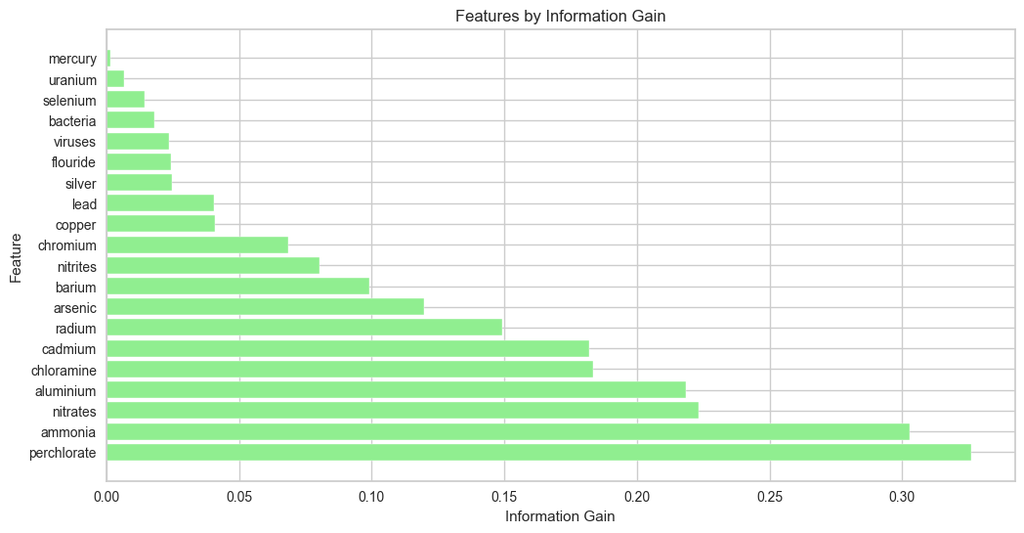

```python
df = pd.read_csv('data_normalisasi.csv')
X = df.drop('is_safe', axis=1)
y = df['is_safe']
# Menghitung Information Gain untuk setiap fitur
information_gains = mutual_info_classif(X, y)

# Menyusun hasil ke dalam DataFrame untuk analisis
feature_scores = pd.DataFrame({'feature': X.columns, 'information_gain': information_gains})
feature_scores = feature_scores.sort_values(by='information_gain', ascending=False)

# Menampilkan hasil Information Gain untuk setiap fitur
print(feature_scores)

# Plotting bar plot untuk perbandingan Information Gain
plt.figure(figsize=(12, 6))
plt.barh(feature_scores['feature'], feature_scores['information_gain'], color='lightgreen')
plt.xlabel('Information Gain')
plt.ylabel('Feature')
plt.title('Features by Information Gain')
plt.show()
```

### Pencarian Fitur Terbaik Light Gradient Boosting Machine

```python
best_accuracy = 0
best_k = 0
best_feature_scores = None
best_selected_feature_names = None
model = None
scaler = None

for k in range(X_train.shape[1], 0, -1):
    # Menghitung nilai korelasi antara setiap fitur dengan target
    k_best_selector = SelectKBest(f_classif, k=k)
    X_train_selected = k_best_selector.fit_transform(X_train, y_train)
    X_test_selected = k_best_selector.transform(X_test)

    # Mendapatkan nama fitur terpilih
    selected_feature_names = X_ros.columns[k_best_selector.get_support(indices=True)]

    # Membuat model Light Gradient Boosting Machine
    lightgbm_model = lightgbm

    # Melatih model menggunakan data training yang telah dinormalisasi dan terpilih fiturnya
    lightgbm_model.fit(X_train_selected, y_train)

    # Melakukan prediksi pada data testing yang telah dinormalisasi dan terpilih fiturnya
    y_pred_lightgbm = lightgbm_model.predict(X_test_selected)

    # Mengukur akurasi model Light Gradient Boosting Machine
    accuracy_lightgbm = accuracy_score(y_test, y_pred_lightgbm)

    # Membandingkan dengan akurasi terbaik sejauh ini
    if accuracy_lightgbm > best_accuracy:
        best_accuracy = accuracy_lightgbm
        best_k = k
        best_selected_feature_names = selected_feature_names
        model = lightgbm_model
        scaler = k_best_selector

        # Menyimpan skor korelasi untuk fitur terpilih
        best_feature_scores = k_best_selector.scores_

# Menampilkan hasil terbaik
print("Jumlah Fitur :", best_k)
print("Best Fitur Light Gradient Boosting Machine :", best_selected_feature_names)
print("\nBest Fitur Scores:")
for feature_name, score in zip(best_selected_feature_names, best_feature_scores):
    print(f"{feature_name}: {score}")

# Menyimpan nama fitur terpilih
joblib.dump(best_selected_feature_names, 'fiturLightGradientBoostingMachine.pkl')
```

[output not shown]

[output cut: 217 more lines]

```
chloramine: 705.6421255995247
chromium: 609.1375894392714
copper: 28.20858760070382
flouride: 2.422481294450292
bacteria: 4.429129304026364
viruses: 173.48651984813026
lead: 0.020259579232659978
nitrates: 87.74346761883795
nitrites: 78.22425346978895
mercury: 33.07324163404674
perchlorate: 94.43379608807072
radium: 92.15581382719945
selenium: 14.847178481026724
silver: 161.19923638886357
uranium: 153.99965019028522
```

```
['fiturLightGradientBoostingMachine.pkl']
```

```python
# Membaca DataFrame
df = pd.read_csv('data_balancing.csv')

# Memuat list fitur yang akan di-drop dari file pickle
LightGradientBoostingMachine_drop = joblib.load('fiturLightGradientBoostingMachine.pkl')

# Menghilangkan 'is_safe' dari setiap nama fitur
LightGradientBoostingMachine_drop = [feature.replace('is_safe', '') for feature in LightGradientBoostingMachine_drop]

# Memilih hanya kolom yang ada di pickle
data_LightGradientBoostingMachine_drop = df[LightGradientBoostingMachine_drop + ['is_safe']]

# Menampilkan DataFrame setelah fitur di-drop
data_LightGradientBoostingMachine_drop.head()
```

|  | aluminium | ammonia | arsenic | barium | cadmium | chloramine | chromium | copper | flouride | bacteria | ... | lead | nitrates | nitrites | mercury | perchlorate | radium | selenium | silver | uranium | is_safe |
| --- | --- | --- | --- | --- | --- | --- | --- | --- | --- | --- | --- | --- | --- | --- | --- | --- | --- | --- | --- | --- | --- |
| 0 | 1.65 | 9.08 | 0.04 | 2.85 | 0.007 | 0.35 | 0.83 | 0.17 | 0.05 | 0.20 | ... | 0.054 | 16.08 | 1.13 | 0.007 | 37.75 | 6.78 | 0.08 | 0.34 | 0.02 | 1 |
| 1 | 2.32 | 21.16 | 0.01 | 3.31 | 0.002 | 5.28 | 0.68 | 0.66 | 0.90 | 0.65 | ... | 0.100 | 2.01 | 1.93 | 0.003 | 32.26 | 3.21 | 0.08 | 0.27 | 0.05 | 1 |
| 2 | 1.01 | 14.02 | 0.04 | 0.58 | 0.008 | 4.24 | 0.53 | 0.02 | 0.99 | 0.05 | ... | 0.078 | 14.16 | 1.11 | 0.006 | 50.28 | 7.07 | 0.07 | 0.44 | 0.01 | 0 |
| 3 | 1.36 | 11.33 | 0.04 | 2.96 | 0.001 | 7.23 | 0.03 | 1.66 | 1.08 | 0.71 | ... | 0.016 | 1.41 | 1.29 | 0.004 | 9.12 | 1.72 | 0.02 | 0.45 | 0.05 | 1 |
| 4 | 0.92 | 24.33 | 0.03 | 0.20 | 0.006 | 2.67 | 0.69 | 0.57 | 0.61 | 0.13 | ... | 0.117 | 6.74 | 1.11 | 0.003 | 16.90 | 2.41 | 0.02 | 0.06 | 0.02 | 1 |

5 rows × 21 columns

### Pencarian Fitur Terbaik Gradient Boosting Classifier

```python
best_accuracy = 0
best_k = 0
best_selected_feature_names = None
best_feature_scores = None
model = None
scaler = None

for k in range(X_train.shape[1], 0, -1):
    # Menghitung nilai korelasi antara setiap fitur dengan target
    k_best_selector = SelectKBest(f_classif, k=k)
    X_train_selected = k_best_selector.fit_transform(X_train, y_train)
    X_test_selected = k_best_selector.transform(X_test)

    # Mendapatkan nama fitur terpilih
    selected_feature_names = X_ros.columns[k_best_selector.get_support(indices=True)]

    # Membuat model Gradient Boosting
    gb_model = gbc

    # Melatih model menggunakan data training yang telah dinormalisasi dan terpilih fiturnya
    gb_model.fit(X_train_selected, y_train)

    # Melakukan prediksi pada data testing yang telah dinormalisasi dan terpilih fiturnya
    y_pred_gb = gb_model.predict(X_test_selected)

    # Mengukur akurasi model Gradient Boosting
    accuracy_gb = accuracy_score(y_test, y_pred_gb)

    # Membandingkan dengan akurasi terbaik sejauh ini
    if accuracy_gb > best_accuracy:
        best_accuracy = accuracy_gb
        best_k = k
        best_selected_feature_names = selected_feature_names
        model = gb_model
        scaler = k_best_selector

        # Menyimpan skor korelasi untuk fitur terpilih
        best_feature_scores = k_best_selector.scores_

# Menampilkan hasil terbaik
print("Jumlah Fitur :", best_k)
print("Best Fitur Gradient Boosting :", best_selected_feature_names)
print("\nBest Fitur Scores:")
for feature_name, score in zip(best_selected_feature_names, best_feature_scores):
    print(f"{feature_name}: {score}")

# Menyimpan nama fitur terpilih
joblib.dump(best_selected_feature_names, 'fiturgradientboosting.pkl')
```

```
Jumlah Fitur : 20
Best Fitur Gradient Boosting : Index(['aluminium', 'ammonia', 'arsenic', 'barium', 'cadmium', 'chloramine',
       'chromium', 'copper', 'flouride', 'bacteria', 'viruses', 'lead',
       'nitrates', 'nitrites', 'mercury', 'perchlorate', 'radium', 'selenium',
       'silver', 'uranium'],
      dtype='object')

Best Fitur Scores:
aluminium: 1768.3190428266103
ammonia: 24.082352474449795
arsenic: 609.9877500155244
barium: 122.3111242384997
cadmium: 1961.2468311627367
chloramine: 705.6421255995247
chromium: 609.1375894392714
copper: 28.20858760070382
flouride: 2.422481294450292
bacteria: 4.429129304026364
viruses: 173.48651984813026
lead: 0.020259579232659978
nitrates: 87.74346761883795
nitrites: 78.22425346978895
mercury: 33.07324163404674
perchlorate: 94.43379608807072
radium: 92.15581382719945
selenium: 14.847178481026724
silver: 161.19923638886357
uranium: 153.99965019028522
```

```
['fiturgradientboosting.pkl']
```

```python
# Membaca DataFrame
df = pd.read_csv('data_balancing.csv')

# Memuat list fitur yang akan di-drop dari file pickle
GradientBoostingClasifier_drop = joblib.load('fiturgradientboosting.pkl')

# Menghilangkan 'is_safe' dari setiap nama fitur
GradientBoostingClasifier_drop = [feature.replace('is_safe', '') for feature in GradientBoostingClasifier_drop]

# Memilih hanya kolom yang ada di pickle
data_GradientBoostingClasifier_drop = df[GradientBoostingClasifier_drop + ['is_safe']]

# Menampilkan DataFrame setelah fitur di-drop
data_GradientBoostingClasifier_drop.head()
```

|  | aluminium | ammonia | arsenic | barium | cadmium | chloramine | chromium | copper | flouride | bacteria | ... | lead | nitrates | nitrites | mercury | perchlorate | radium | selenium | silver | uranium | is_safe |
| --- | --- | --- | --- | --- | --- | --- | --- | --- | --- | --- | --- | --- | --- | --- | --- | --- | --- | --- | --- | --- | --- |
| 0 | 1.65 | 9.08 | 0.04 | 2.85 | 0.007 | 0.35 | 0.83 | 0.17 | 0.05 | 0.20 | ... | 0.054 | 16.08 | 1.13 | 0.007 | 37.75 | 6.78 | 0.08 | 0.34 | 0.02 | 1 |
| 1 | 2.32 | 21.16 | 0.01 | 3.31 | 0.002 | 5.28 | 0.68 | 0.66 | 0.90 | 0.65 | ... | 0.100 | 2.01 | 1.93 | 0.003 | 32.26 | 3.21 | 0.08 | 0.27 | 0.05 | 1 |
| 2 | 1.01 | 14.02 | 0.04 | 0.58 | 0.008 | 4.24 | 0.53 | 0.02 | 0.99 | 0.05 | ... | 0.078 | 14.16 | 1.11 | 0.006 | 50.28 | 7.07 | 0.07 | 0.44 | 0.01 | 0 |
| 3 | 1.36 | 11.33 | 0.04 | 2.96 | 0.001 | 7.23 | 0.03 | 1.66 | 1.08 | 0.71 | ... | 0.016 | 1.41 | 1.29 | 0.004 | 9.12 | 1.72 | 0.02 | 0.45 | 0.05 | 1 |
| 4 | 0.92 | 24.33 | 0.03 | 0.20 | 0.006 | 2.67 | 0.69 | 0.57 | 0.61 | 0.13 | ... | 0.117 | 6.74 | 1.11 | 0.003 | 16.90 | 2.41 | 0.02 | 0.06 | 0.02 | 1 |

5 rows × 21 columns

### Pencarian Fitur Terbaik Random Forest

```python
best_accuracy = 0
best_k = 0
best_selected_feature_names = None
best_feature_scores = None
model = None
scaler = None

for k in range(X_train.shape[1], 0, -1):
    # Menghitung nilai korelasi antara setiap fitur dengan target
    k_best_selector = SelectKBest(f_classif, k=k)
    X_train_selected = k_best_selector.fit_transform(X_train, y_train)
    X_test_selected = k_best_selector.transform(X_test)

    # Mendapatkan nama fitur terpilih
    selected_feature_names = X_ros.columns[k_best_selector.get_support(indices=True)]

    # Membuat model Random Forest
    rf_model = rf

    # Melatih model menggunakan data training yang telah dinormalisasi dan terpilih fiturnya
    rf_model.fit(X_train_selected, y_train)

    # Melakukan prediksi pada data testing yang telah dinormalisasi dan terpilih fiturnya
    y_pred_rf = rf_model.predict(X_test_selected)

    # Mengukur akurasi model Random Forest
    accuracy_rf = accuracy_score(y_test, y_pred_rf)

    # Membandingkan dengan akurasi terbaik sejauh ini
    if accuracy_rf > best_accuracy:
        best_accuracy = accuracy_rf
        best_k = k
        best_selected_feature_names = selected_feature_names
        model = rf_model
        scaler = k_best_selector

        # Menyimpan skor korelasi untuk fitur terpilih
        best_feature_scores = k_best_selector.scores_

# Menampilkan hasil terbaik
print("Jumlah Fitur :", best_k)
print("Best Fitur Random Forest:", best_selected_feature_names)
print("\nBest Fitur Scores:")
for feature_name, score in zip(best_selected_feature_names, best_feature_scores):
    print(f"{feature_name}: {score}")

# Menyimpan nama fitur terpilih
joblib.dump(best_selected_feature_names, 'fiturrandomforest.pkl')
```

```
Jumlah Fitur : 17
Best Fitur Random Forest: Index(['aluminium', 'ammonia', 'arsenic', 'barium', 'cadmium', 'chloramine',
       'chromium', 'copper', 'viruses', 'nitrates', 'nitrites', 'mercury',
       'perchlorate', 'radium', 'selenium', 'silver', 'uranium'],
      dtype='object')

Best Fitur Scores:
aluminium: 1768.3190428266103
ammonia: 24.082352474449795
arsenic: 609.9877500155244
barium: 122.3111242384997
cadmium: 1961.2468311627367
chloramine: 705.6421255995247
chromium: 609.1375894392714
copper: 28.20858760070382
viruses: 2.422481294450292
nitrates: 4.429129304026364
nitrites: 173.48651984813026
mercury: 0.020259579232659978
perchlorate: 87.74346761883795
radium: 78.22425346978895
selenium: 33.07324163404674
silver: 94.43379608807072
uranium: 92.15581382719945
```

```
['fiturrandomforest.pkl']
```

```python
# Membaca DataFrame
df = pd.read_csv('data_balancing.csv')

# Memuat list fitur yang akan di-drop dari file pickle
RandomForest_drop = joblib.load('fiturrandomforest.pkl')

# Menghilangkan 'is_safe' dari setiap nama fitur
RandomForest_drop = [feature.replace('is_safe', '') for feature in RandomForest_drop]

# Memilih hanya kolom yang ada di pickle
data_RandomForest_drop = df[RandomForest_drop + ['is_safe']]

# Menampilkan DataFrame setelah fitur di-drop
data_RandomForest_drop.head()
```

|  | aluminium | ammonia | arsenic | barium | cadmium | chloramine | chromium | copper | viruses | nitrates | nitrites | mercury | perchlorate | radium | selenium | silver | uranium | is_safe |
| --- | --- | --- | --- | --- | --- | --- | --- | --- | --- | --- | --- | --- | --- | --- | --- | --- | --- | --- |
| 0 | 1.65 | 9.08 | 0.04 | 2.85 | 0.007 | 0.35 | 0.83 | 0.17 | 0.000 | 16.08 | 1.13 | 0.007 | 37.75 | 6.78 | 0.08 | 0.34 | 0.02 | 1 |
| 1 | 2.32 | 21.16 | 0.01 | 3.31 | 0.002 | 5.28 | 0.68 | 0.66 | 0.650 | 2.01 | 1.93 | 0.003 | 32.26 | 3.21 | 0.08 | 0.27 | 0.05 | 1 |
| 2 | 1.01 | 14.02 | 0.04 | 0.58 | 0.008 | 4.24 | 0.53 | 0.02 | 0.003 | 14.16 | 1.11 | 0.006 | 50.28 | 7.07 | 0.07 | 0.44 | 0.01 | 0 |
| 3 | 1.36 | 11.33 | 0.04 | 2.96 | 0.001 | 7.23 | 0.03 | 1.66 | 0.710 | 1.41 | 1.29 | 0.004 | 9.12 | 1.72 | 0.02 | 0.45 | 0.05 | 1 |
| 4 | 0.92 | 24.33 | 0.03 | 0.20 | 0.006 | 2.67 | 0.69 | 0.57 | 0.001 | 6.74 | 1.11 | 0.003 | 16.90 | 2.41 | 0.02 | 0.06 | 0.02 | 1 |

### Decision Tree Clasifier

```python
best_accuracy = 0
best_k = 0
best_selected_feature_names = None
best_feature_scores = None
model = None
scaler = None

for k in range(X_train.shape[1], 0, -1):
    # Menghitung nilai korelasi antara setiap fitur dengan target
    k_best_selector = SelectKBest(f_classif, k=k)
    X_train_selected = k_best_selector.fit_transform(X_train, y_train)
    X_test_selected = k_best_selector.transform(X_test)

    # Mendapatkan nama fitur terpilih
    selected_feature_names = X_ros.columns[k_best_selector.get_support(indices=True)]

    # Membuat model Decision Tree
    dt_model = DecisionTreeClassifier()  # Ganti dengan parameter yang sesuai

    # Melatih model menggunakan data training yang telah dinormalisasi dan terpilih fiturnya
    dt_model.fit(X_train_selected, y_train)

    # Melakukan prediksi pada data testing yang telah dinormalisasi dan terpilih fiturnya
    y_pred_dt = dt_model.predict(X_test_selected)

    # Mengukur akurasi model Decision Tree
    accuracy_dt = accuracy_score(y_test, y_pred_dt)

    # Membandingkan dengan akurasi terbaik sejauh ini
    if accuracy_dt > best_accuracy:
        best_accuracy = accuracy_dt
        best_k = k
        best_selected_feature_names = selected_feature_names
        model = dt_model
        scaler = k_best_selector

        # Menyimpan skor korelasi untuk fitur terpilih
        best_feature_scores = k_best_selector.scores_

# Menampilkan hasil terbaik
print("Jumlah Fitur :", best_k)
print("Best Fitur Decision Tree:", best_selected_feature_names)
print("\nBest Fitur Scores:")
for feature_name, score in zip(best_selected_feature_names, best_feature_scores):
    print(f"{feature_name}: {score}")

# Menyimpan nama fitur terpilih
joblib.dump(best_selected_feature_names, 'fiturdecisiontree.pkl')
```

```
Jumlah Fitur : 20
Best Fitur Decision Tree: Index(['aluminium', 'ammonia', 'arsenic', 'barium', 'cadmium', 'chloramine',
       'chromium', 'copper', 'flouride', 'bacteria', 'viruses', 'lead',
       'nitrates', 'nitrites', 'mercury', 'perchlorate', 'radium', 'selenium',
       'silver', 'uranium'],
      dtype='object')

Best Fitur Scores:
aluminium: 1768.3190428266103
ammonia: 24.082352474449795
arsenic: 609.9877500155244
barium: 122.3111242384997
cadmium: 1961.2468311627367
chloramine: 705.6421255995247
chromium: 609.1375894392714
copper: 28.20858760070382
flouride: 2.422481294450292
bacteria: 4.429129304026364
viruses: 173.48651984813026
lead: 0.020259579232659978
nitrates: 87.74346761883795
nitrites: 78.22425346978895
mercury: 33.07324163404674
perchlorate: 94.43379608807072
radium: 92.15581382719945
selenium: 14.847178481026724
silver: 161.19923638886357
uranium: 153.99965019028522
```

```
['fiturdecisiontree.pkl']
```

```python
best_accuracy = 0
best_k = 0
best_selected_feature_names = None
best_feature_scores = None
model = None
scaler = None

for k in range(X_train.shape[1], 0, -1):
    # Menghitung nilai korelasi antara setiap fitur dengan target
    k_best_selector = SelectKBest(f_classif, k=k)
    X_train_selected = k_best_selector.fit_transform(X_train, y_train)
    X_test_selected = k_best_selector.transform(X_test)

    # Mendapatkan nama fitur terpilih
    selected_feature_names = X_ros.columns[k_best_selector.get_support(indices=True)]

    # Membuat model Random Forest
    dt_model = dt

    # Melatih model menggunakan data training yang telah dinormalisasi dan terpilih fiturnya
    dt_model.fit(X_train_selected, y_train)

    # Melakukan prediksi pada data testing yang telah dinormalisasi dan terpilih fiturnya
    y_pred_dt = dt_model.predict(X_test_selected)

    # Mengukur akurasi model Random Forest
    accuracy_dt = accuracy_score(y_test, y_pred_dt)

    # Membandingkan dengan akurasi terbaik sejauh ini
    if accuracy_dt > best_accuracy:
        best_accuracy = accuracy_dt
        best_k = k
        best_selected_feature_names = selected_feature_names
        model = dt_model
        scaler = k_best_selector

        # Menyimpan skor korelasi untuk fitur terpilih
        best_feature_scores = k_best_selector.scores_

# Menampilkan hasil terbaik
print("Jumlah Fitur :", best_k)
print("Best Fitur Decision Tree:", best_selected_feature_names)
print("\nBest Fitur Scores:")
for feature_name, score in zip(best_selected_feature_names, best_feature_scores):
    print(f"{feature_name}: {score}")

# Menyimpan nama fitur terpilih
joblib.dump(best_selected_feature_names, 'fiturdecisiontree.pkl')
```

```
Jumlah Fitur : 19
Best Fitur Decision Tree: Index(['aluminium', 'ammonia', 'arsenic', 'barium', 'cadmium', 'chloramine',
       'chromium', 'copper', 'flouride', 'bacteria', 'viruses', 'nitrates',
       'nitrites', 'mercury', 'perchlorate', 'radium', 'selenium', 'silver',
       'uranium'],
      dtype='object')

Best Fitur Scores:
aluminium: 1768.3190428266103
ammonia: 24.082352474449795
arsenic: 609.9877500155244
barium: 122.3111242384997
cadmium: 1961.2468311627367
chloramine: 705.6421255995247
chromium: 609.1375894392714
copper: 28.20858760070382
flouride: 2.422481294450292
bacteria: 4.429129304026364
viruses: 173.48651984813026
nitrates: 0.020259579232659978
nitrites: 87.74346761883795
mercury: 78.22425346978895
perchlorate: 33.07324163404674
radium: 94.43379608807072
selenium: 92.15581382719945
silver: 14.847178481026724
uranium: 161.19923638886357
```

```
['fiturdecisiontree.pkl']
```

```python
# Membaca DataFrame
df = pd.read_csv('data_balancing.csv')

# Memuat list fitur yang akan di-drop dari file pickle
DecisionTree_drop = joblib.load('fiturdecisiontree.pkl')

# Menghilangkan 'is_safe' dari setiap nama fitur
DecisionTree_drop = [feature.replace('is_safe', '') for feature in DecisionTree_drop]

# Memilih hanya kolom yang ada di pickle
data_DecisionTree_drop = df[DecisionTree_drop + ['is_safe']]

# Menampilkan DataFrame setelah fitur di-drop
data_DecisionTree_drop.head()
```

|  | aluminium | ammonia | arsenic | barium | cadmium | chloramine | chromium | copper | flouride | bacteria | viruses | nitrates | nitrites | mercury | perchlorate | radium | selenium | silver | uranium | is_safe |
| --- | --- | --- | --- | --- | --- | --- | --- | --- | --- | --- | --- | --- | --- | --- | --- | --- | --- | --- | --- | --- |
| 0 | 1.65 | 9.08 | 0.04 | 2.85 | 0.007 | 0.35 | 0.83 | 0.17 | 0.05 | 0.20 | 0.000 | 16.08 | 1.13 | 0.007 | 37.75 | 6.78 | 0.08 | 0.34 | 0.02 | 1 |
| 1 | 2.32 | 21.16 | 0.01 | 3.31 | 0.002 | 5.28 | 0.68 | 0.66 | 0.90 | 0.65 | 0.650 | 2.01 | 1.93 | 0.003 | 32.26 | 3.21 | 0.08 | 0.27 | 0.05 | 1 |
| 2 | 1.01 | 14.02 | 0.04 | 0.58 | 0.008 | 4.24 | 0.53 | 0.02 | 0.99 | 0.05 | 0.003 | 14.16 | 1.11 | 0.006 | 50.28 | 7.07 | 0.07 | 0.44 | 0.01 | 0 |
| 3 | 1.36 | 11.33 | 0.04 | 2.96 | 0.001 | 7.23 | 0.03 | 1.66 | 1.08 | 0.71 | 0.710 | 1.41 | 1.29 | 0.004 | 9.12 | 1.72 | 0.02 | 0.45 | 0.05 | 1 |
| 4 | 0.92 | 24.33 | 0.03 | 0.20 | 0.006 | 2.67 | 0.69 | 0.57 | 0.61 | 0.13 | 0.001 | 6.74 | 1.11 | 0.003 | 16.90 | 2.41 | 0.02 | 0.06 | 0.02 | 1 |

### Ada Boost Classifier

```python
from sklearn.feature_selection import SelectKBest, f_classif
from sklearn.ensemble import AdaBoostClassifier
from sklearn.metrics import accuracy_score
import joblib

best_accuracy = 0
best_k = 0
best_selected_feature_names = None
best_feature_scores = None
model = None
scaler = None

for k in range(X_train.shape[1], 0, -1):
    # Menghitung nilai korelasi antara setiap fitur dengan target
    k_best_selector = SelectKBest(f_classif, k=k)
    X_train_selected = k_best_selector.fit_transform(X_train, y_train)
    X_test_selected = k_best_selector.transform(X_test)

    # Mendapatkan nama fitur terpilih
    selected_feature_names = X_ros.columns[k_best_selector.get_support(indices=True)]

    # Membuat model Adaboost
    adaboost_model = AdaBoostClassifier(n_estimators=50, random_state=42)  # Ganti dengan parameter yang sesuai

    # Melatih model menggunakan data training yang telah dinormalisasi dan terpilih fiturnya
    adaboost_model.fit(X_train_selected, y_train)

    # Melakukan prediksi pada data testing yang telah dinormalisasi dan terpilih fiturnya
    y_pred_adaboost = adaboost_model.predict(X_test_selected)

    # Mengukur akurasi model Adaboost
    accuracy_adaboost = accuracy_score(y_test, y_pred_adaboost)

    # Menyimpan skor korelasi untuk fitur terpilih
    feature_scores = k_best_selector.scores_

    # Membandingkan dengan akurasi terbaik sejauh ini
    if accuracy_adaboost > best_accuracy:
        best_accuracy = accuracy_adaboost
        best_k = k
        best_selected_feature_names = selected_feature_names
        best_feature_scores = feature_scores
        model = adaboost_model
        scaler = k_best_selector

# Menampilkan hasil terbaik
print("Jumlah Fitur :", best_k)
print("Best Fitur Adaboost:", best_selected_feature_names)
print("\nBest Fitur Scores:")
for feature_name, score in zip(best_selected_feature_names, best_feature_scores):
    print(f"{feature_name}: {score}")

# Menyimpan nama fitur terpilih
joblib.dump(best_selected_feature_names, 'fituradaboost.pkl')
```

```
Jumlah Fitur : 20
Best Fitur Adaboost: Index(['aluminium', 'ammonia', 'arsenic', 'barium', 'cadmium', 'chloramine',
       'chromium', 'copper', 'flouride', 'bacteria', 'viruses', 'lead',
       'nitrates', 'nitrites', 'mercury', 'perchlorate', 'radium', 'selenium',
       'silver', 'uranium'],
      dtype='object')

Best Fitur Scores:
aluminium: 1768.3190428266103
ammonia: 24.082352474449795
arsenic: 609.9877500155244
barium: 122.3111242384997
cadmium: 1961.2468311627367
chloramine: 705.6421255995247
chromium: 609.1375894392714
copper: 28.20858760070382
flouride: 2.422481294450292
bacteria: 4.429129304026364
viruses: 173.48651984813026
lead: 0.020259579232659978
nitrates: 87.74346761883795
nitrites: 78.22425346978895
mercury: 33.07324163404674
perchlorate: 94.43379608807072
radium: 92.15581382719945
selenium: 14.847178481026724
silver: 161.19923638886357
uranium: 153.99965019028522
```

```
['fituradaboost.pkl']
```

```python
# Membaca DataFrame
df = pd.read_csv('data_balancing.csv')

# Memuat list fitur yang akan di-drop dari file pickle
Adaboost_drop = joblib.load('fituradaboost.pkl')

# Menghilangkan 'is_safe' dari setiap nama fitur
Adaboost_drop = [feature.replace('is_safe', '') for feature in Adaboost_drop]

# Memilih hanya kolom yang ada di pickle
data_Adaboost_drop = df[Adaboost_drop + ['is_safe']]

# Menampilkan DataFrame setelah fitur di-drop
data_Adaboost_drop.head()
```

|  | aluminium | ammonia | arsenic | barium | cadmium | chloramine | chromium | copper | flouride | bacteria | ... | lead | nitrates | nitrites | mercury | perchlorate | radium | selenium | silver | uranium | is_safe |
| --- | --- | --- | --- | --- | --- | --- | --- | --- | --- | --- | --- | --- | --- | --- | --- | --- | --- | --- | --- | --- | --- |
| 0 | 1.65 | 9.08 | 0.04 | 2.85 | 0.007 | 0.35 | 0.83 | 0.17 | 0.05 | 0.20 | ... | 0.054 | 16.08 | 1.13 | 0.007 | 37.75 | 6.78 | 0.08 | 0.34 | 0.02 | 1 |
| 1 | 2.32 | 21.16 | 0.01 | 3.31 | 0.002 | 5.28 | 0.68 | 0.66 | 0.90 | 0.65 | ... | 0.100 | 2.01 | 1.93 | 0.003 | 32.26 | 3.21 | 0.08 | 0.27 | 0.05 | 1 |
| 2 | 1.01 | 14.02 | 0.04 | 0.58 | 0.008 | 4.24 | 0.53 | 0.02 | 0.99 | 0.05 | ... | 0.078 | 14.16 | 1.11 | 0.006 | 50.28 | 7.07 | 0.07 | 0.44 | 0.01 | 0 |
| 3 | 1.36 | 11.33 | 0.04 | 2.96 | 0.001 | 7.23 | 0.03 | 1.66 | 1.08 | 0.71 | ... | 0.016 | 1.41 | 1.29 | 0.004 | 9.12 | 1.72 | 0.02 | 0.45 | 0.05 | 1 |
| 4 | 0.92 | 24.33 | 0.03 | 0.20 | 0.006 | 2.67 | 0.69 | 0.57 | 0.61 | 0.13 | ... | 0.117 | 6.74 | 1.11 | 0.003 | 16.90 | 2.41 | 0.02 | 0.06 | 0.02 | 1 |

5 rows × 21 columns

# Modeling

## Light Gradient Boosting Machine

Metode Light Gradient Boosting Machine (LightGBM) merupakan salah satu algoritma machine learning yang termasuk dalam kategori ensemble learning, khususnya dalam keluarga algoritma gradient boosting. LightGBM dikembangkan oleh Microsoft dan dirancang untuk memberikan kinerja yang cepat dan efisien, terutama pada dataset yang besar.

Berikut adalah beberapa karakteristik utama dari LightGBM:

1. Gradient Boosting Framework, jadi LightGBM merupakan implementasi dari algoritma gradient boosting, yang berfokus pada membangun model prediktif dengan cara menggabungkan beberapa model lemah (weak learners) menjadi satu model yang kuat. Proses ini dilakukan secara iteratif, dengan setiap iterasi bertujuan untuk memperbaiki kesalahan prediksi yang dibuat oleh model sebelumnya.
2. Leaf-wise Growth Strategy, Salah satu fitur utama dari LightGBM adalah strategi pertumbuhan pohon secara daun (leaf-wise). Berbeda dengan pendekatan level-wise pada algoritma gradient boosting lainnya, LightGBM membangun pohon dengan mengekspansi daun yang memberikan kontribusi terbesar pada penurunan kesalahan (loss). Strategi ini membantu meningkatkan efisiensi karena hanya daun yang signifikan yang diperluas.
3. Histogram-Based Learning, LightGBM menggunakan histogram untuk memproses data pada setiap iterasi pembelajaran. Histogram adalah representasi diskrit dari distribusi data, yang membantu mengurangi waktu komputasi. Proses pembelajaran pada LightGBM membagi dataset ke dalam beberapa bucket histogram, dan kemudian menghitung statistik di setiap bucket untuk mempercepat pembelajaran.
4. Categorical Feature Support, LightGBM memiliki dukungan khusus untuk fitur kategorikal tanpa perlu melakukan pre-processing one-hot encoding. Ini membuatnya lebih efisien untuk menangani dataset dengan fitur kategorikal.
5. Distributed Training, LightGBM mendukung pelatihan terdistribusi, yang memungkinkan pengguna melatih model pada dataset yang sangat besar dengan menggunakan beberapa sumber daya komputasi secara bersamaan.
6. Regularization,LightGBM menyediakan opsi untuk menerapkan regularisasi pada pohon untuk mencegah overfitting. Regularisasi dapat diatur menggunakan parameter seperti lambda dan alpha.
7. Kecepatan dan Skalabilitas, Salah satu keunggulan utama LightGBM adalah kecepatan eksekusinya yang tinggi dan skalabilitasnya terhadap ukuran dataset. Hal ini membuatnya menjadi pilihan populer untuk tugas-tugas yang melibatkan data besar.

```python
from sklearn.preprocessing import RobustScaler

X = data_LightGradientBoostingMachine_drop.drop('is_safe', axis=1)
y = data_LightGradientBoostingMachine_drop['is_safe']
X_train_lgbm, X_test_lgbm, y_train_lgbm, y_test_lgbm = train_test_split(X, y, test_size=0.2, random_state=42)

RobustScaler = RobustScaler()
X_train_lightgbm = RobustScaler.fit_transform(X_train_lgbm)
X_test_lightgbm = RobustScaler.transform(X_test_lgbm)

lightgbm_model = lightgbm
lightgbm_model.fit(X_train_lightgbm, y_train_lgbm)
y_pred_lightgbm = lightgbm_model.predict(X_test_lightgbm)
accuracy_lightgbm = accuracy_score(y_test_lgbm, y_pred_lightgbm)
print("\nAccuracy metode Light Gradient Boosting Machine :",accuracy_lightgbm*100)

joblib.dump(RobustScaler, 'saclelightgbm.pkl')
joblib.dump(lightgbm_model, 'modellightgbm.pkl')
```

```
[LightGBM] [Info] Number of positive: 4180, number of negative: 4197
[LightGBM] [Info] Auto-choosing col-wise multi-threading, the overhead of testing was 0.001871 seconds.
You can set `force_col_wise=true` to remove the overhead.
[LightGBM] [Info] Total Bins 3018
[LightGBM] [Info] Number of data points in the train set: 8377, number of used features: 20
[LightGBM] [Info] [binary:BoostFromScore]: pavg=0.498985 -> initscore=-0.004059
[LightGBM] [Info] Start training from score -0.004059

Accuracy metode Light Gradient Boosting Machine : 98.37708830548925
```

```
['modellightgbm.pkl']
```

## Gradient Boosting Classifier

Metode Gradient Boosting adalah salah satu pendekatan dalam machine learning yang termasuk dalam kategori ensemble learning. Ensemble learning melibatkan penggabungan beberapa model lemah (weak learners) untuk membentuk model yang lebih kuat. Gradient Boosting secara khusus fokus pada pengurangan kesalahan prediksi dengan memperhatikan kesalahan model sebelumnya.

Berikut adalah konsep dasar dari metode Gradient Boosting:

1. Weak learners adalah model prediktif yang memiliki performa yang sedikit di atas random chance. Contohnya termasuk decision trees dengan kedalaman yang sangat terbatas (stump) atau regresi linear sederhana. Dalam konteks Gradient Boosting, sejumlah besar weak learners akan digabungkan untuk membentuk model yang kuat. Sequential Model Building:
2. Proses Gradient Boosting melibatkan pembangunan model secara iteratif. Pada setiap iterasi, model baru ditambahkan untuk mengkompensasi kesalahan prediksi yang belum ditangani oleh model sebelumnya. Model yang baru ditambahkan harus "mengajar" untuk kesalahan yang ada. Ini dilakukan dengan meminimalkan residual error (selisih antara prediksi aktual dan prediksi model sebelumnya) menggunakan weak learner.
3. Loss function (fungsi kerugian) digunakan untuk mengukur sejauh mana model saat ini memberikan prediksi yang benar atau mendekati target aktual. Pada setiap iterasi, model berusaha meminimalkan nilai loss function. Contoh loss function untuk regresi adalah Mean Squared Error (MSE), sementara untuk klasifikasi bisa menggunakan log-likelihood atau Gini Index.
4. Gradient descent digunakan untuk menemukan parameter model yang meminimalkan loss function. Pada setiap iterasi, model baru ditambahkan dengan menyesuaikan parameter (misalnya, bobot pohon pada decision tree) dalam arah yang berlawanan dengan gradien loss function. Proses ini memungkinkan model untuk fokus pada bagian dataset yang sulit diprediksi oleh model sebelumnya.
5. Shrinkage adalah parameter yang mengontrol seberapa besar kita akan "mempelajari" dari setiap model tambahan. Nilai shrinkage yang lebih rendah memerlukan lebih banyak iterasi untuk mencapai kinerja yang baik, tetapi dapat meningkatkan kestabilan model.
6. Beberapa implementasi Gradient Boosting, seperti XGBoost atau LightGBM, memiliki opsi untuk menerapkan teknik regularisasi untuk mencegah overfitting. Regularisasi dapat diatur dengan menggunakan parameter tertentu, seperti lambda dan alpha.
7. Gradient Boosting mirip dengan metode AdaBoost, tetapi ada perbedaan kunci. Jika AdaBoost memberikan "perhatian lebih" pada contoh yang salah diprediksi sebelumnya, Gradient Boosting fokus pada residual errors atau gradien loss function.

```python
from sklearn.preprocessing import RobustScaler

X = data_GradientBoostingClasifier_drop.drop('is_safe', axis=1)
y = data_GradientBoostingClasifier_drop['is_safe']
X_train_gbc, X_test_gbc, y_train_gbc, y_test_gbc = train_test_split(X, y, test_size=0.2, random_state=42)

RobustScaler = RobustScaler()
X_train_GradientBoosting = RobustScaler.fit_transform(X_train_gbc)
X_test_GradientBoosting = RobustScaler.transform(X_test_gbc)

gbc_model = gbc
gbc_model.fit(X_train_GradientBoosting, y_train_gbc)
y_pred_gbc = gbc_model.predict(X_test_GradientBoosting)
accuracy_gbc = accuracy_score(y_test_gbc, y_pred_gbc)
print("Accuracy metode Gradient Boosting Clasifier :",accuracy_gbc*100)

joblib.dump(RobustScaler, 'saclergbc.pkl')
joblib.dump(gbc_model, 'modelgbc.pkl')
```

```
Accuracy metode Gradient Boosting Clasifier : 95.13126491646779
```

```
['modelgbc.pkl']
```

## Random Forest

Random Forest adalah sebuah metode ensemble learning yang digunakan dalam pemodelan prediktif dan klasifikasi. Ensemble learning melibatkan penggabungan hasil dari beberapa model untuk meningkatkan kinerja dan akurasi keseluruhan. Random Forest khususnya menggunakan pohon keputusan sebagai model dasar dan menggabungkan prediksi dari beberapa pohon keputusan untuk membuat keputusan akhir.

Random Forest efektif untuk berbagai jenis tugas seperti klasifikasi dan regresi, dan sering digunakan karena kemampuannya yang baik dalam menangani data yang kompleks dan beragam. Keunggulan utamanya termasuk kemampuan untuk mengatasi overfitting, memberikan nilai penting untuk fitur, dan memberikan performa yang baik secara umum.

Berikut adalah contoh sederhana bagaimana kita bisa menghitung prediksi menggunakan Random Forest dengan tiga pohon:

Misalkan kita memiliki tiga pohon keputusan yang masing-masing memberikan prediksi sebagai berikut untuk suatu titik data:

| Pohon | Prediksi |
| --- | --- |
| 1 | A |
| 2 | B |
| 3 | A |

Dalam hal ini, Random Forest akan memberikan prediksi akhir "Kelas A" karena ini adalah kelas yang paling sering diprediksi oleh pohon-pohon dalam hutan.

- **Contoh Penerapan**

**1. Persiapan Data**

| Usia | Tinggi Badan | Berat Badan | Target Kategori |
| --- | --- | --- | --- |
| 25 | 170 | 70 | Normal |
| 30 | 170 | 60 | Normal |
| 35 | 180 | 80 | Obesitas |

**2. Pelatihan Model**

Kedua, kita melatih model Random Forest menggunakan data historis tersebut. Model akan mempelajari hubungan kompleks antara "Usia", "Tinggi Badan", "Berat Badan", dan target "Kategori Obesitas".

**3. Penggunaan Model Untuk Prediksi**

Setelah melatih model, kita dapat menggunakannya untuk memprediksi kategori obesitas berdasarkan fitur-fitur baru. Misalkan kita memiliki data baru seperti berikut:

| Usia | Tinggi Badan | Berat Badan |
| --- | --- | --- |
| 28 | 175 | 75 |

**4. Hasil Prediksi** Model kita kemudian memberikan prediksi kategori obesitas berikut:

| Usia | Tinggi Badan | Berat Badan | Target Kategori |
| --- | --- | --- | --- |
| 28 | 175 | 75 | Obesitas |

Dalam contoh ini, model Random Forest memprediksi bahwa dengan usia 28 tahun, tinggi badan 175 cm, dan berat badan 75 kg, seseorang termasuk dalam kategori "Obesitas".

```python
from sklearn.preprocessing import RobustScaler

X = data_RandomForest_drop.drop('is_safe', axis=1)
y = data_RandomForest_drop['is_safe']
X_train_rf, X_test_rf, y_train_rf, y_test_rf = train_test_split(X, y, test_size=0.2, random_state=42)

RobustScaler = RobustScaler()
X_train_RandomForest = RobustScaler.fit_transform(X_train_rf)
X_test_RandomForest = RobustScaler.transform(X_test_rf)

rf_model = rf
rf_model.fit(X_train_RandomForest, y_train_rf)
y_pred_rf = rf_model.predict(X_test_RandomForest)
accuracy_rf = accuracy_score(y_test_rf, y_pred_rf)
print("Accuracy metode Random Forest :",accuracy_rf*100)

joblib.dump(RobustScaler, 'saclerrandomforest.pkl')
joblib.dump(rf_model, 'modelrandomforest.pkl')
```

```
Accuracy metode Random Forest : 98.75894988066825
```

```
['modelrandomforest.pkl']
```

## Decision Tree Clasifier

Decision Tree, atau pohon keputusan, adalah salah satu algoritma pembelajaran mesin yang dapat digunakan untuk tugas klasifikasi dan regresi. Algoritma ini membangun struktur pohon di mana setiap simpul (node) mewakili keputusan berdasarkan fitur-fitur data. Pada setiap simpul, algoritma membuat keputusan berdasarkan fitur tertentu, sehingga memungkinkan pemisahan data menjadi kelompok yang semakin homogen.

Keunggulan Decision Tree:

1. Interpretabilitas: Pohon keputusan dapat dengan mudah diinterpretasikan oleh manusia karena strukturnya mirip dengan keputusan yang diambil berdasarkan aturan sederhana.
2. Penanganan Fitur Non-Lineer: Decision Tree dapat menangani hubungan non-linear antara fitur dan target.
3. Skalabilitas: Cocok untuk dataset dengan banyak fitur dan data yang cukup besar.
- Contoh Penerapan:
1. Persiapan Data Misalkan kita memiliki data mengenai konsumen yang ingin kita kelompokkan berdasarkan keputusan pembelian suatu produk. Data tersebut mungkin terlihat seperti ini:

| Umur | Pendapatan | Pendidikan | Keputusan Pembelian |
| --- | --- | --- | --- |
| 25 | 50000 | Sarjana | Ya |
| 35 | 75000 | Master | Tidak |
| 45 | 100000 | Doktor | Ya |

1. Pelatihan Model Selanjutnya, kita melatih model Decision Tree menggunakan data historis tersebut. Model akan mempelajari aturan-aturan keputusan berdasarkan fitur-fitur seperti "Umur", "Pendapatan", dan "Pendidikan".
2. Penggunaan Model Untuk Prediksi Setelah pelatihan, kita dapat menggunakan model untuk memprediksi keputusan pembelian konsumen baru. Misalkan kita memiliki data baru:

| Umur | Pendapatan | Pendidikan |
| --- | --- | --- |
| 30 | 60000 | Diploma |

1. Hasil Prediksi

Model Decision Tree kemudian memberikan prediksi keputusan pembelian, misalnya, "Ya" atau "Tidak", berdasarkan aturan yang telah dipelajari dari data historis.

```python
from sklearn.preprocessing import RobustScaler

X = data_DecisionTree_drop.drop('is_safe', axis=1)
y = data_DecisionTree_drop['is_safe']
X_train_dt, X_test_dt, y_train_dt, y_test_dt = train_test_split(X, y, test_size=0.2, random_state=42)

RobustScaler = RobustScaler()
X_train_DecisionTree = RobustScaler.fit_transform(X_train_dt)
X_test_DecisionTree = RobustScaler.transform(X_test_dt)

dt_model = dt
dt_model.fit(X_train_DecisionTree, y_train_dt)
y_pred_dt = dt_model.predict(X_test_DecisionTree)
accuracy_dt = accuracy_score(y_test_dt, y_pred_dt)
print("Accuracy metode Decision Tree :",accuracy_dt*100)

joblib.dump(RobustScaler, 'saclerdecisiontree.pkl')
joblib.dump(dt_model, 'modeldecisiontree.pkl')
```

```
Accuracy metode Decision Tree : 98.32935560859188
```

```
['modeldecisiontree.pkl']
```

## Ada Boost Classifier

Adaboost menggabungkan hasil dari sejumlah besar weak classifiers (misalnya, pohon keputusan yang sangat sederhana) untuk membentuk model yang kuat. Setiap weak classifier diberi bobot berdasarkan seberapa baik mereka menangani sampel pada iterasi sebelumnya. Proses ini dilakukan secara iteratif, dan pada setiap iterasi, bobot baru diberikan pada sampel yang salah diprediksi pada iterasi sebelumnya.

Dengan kata lain, jika kita memiliki M weak classifiers, prediksi model ensemble Adaboost (( F(x) )) dapat dihitung dengan:

$$ F(x) = \sum_{m=1}^{M} \alpha_m \cdot f_m(x) $$

di mana:

- $ F(x) $ adalah prediksi model ensemble.
- $ \alpha_m $ adalah bobot yang diberikan pada weak classifier ke-m.
- $ f_m(x) $ adalah prediksi dari weak classifier ke-m.

Bobot $ \alpha_m $ dihitung berdasarkan tingkat kesalahan weak classifier pada iterasi sebelumnya. Semakin baik weak classifier menangani sampel, semakin besar bobotnya.

Bentuk umum ini mencerminkan kombinasi linear dari weak classifiers, dan dengan strategi ini, Adaboost dapat memperbaiki performa model terhadap sampel yang sulit diprediksi oleh model sebelumnya.

```python
from sklearn.preprocessing import RobustScaler

X = data_Adaboost_drop.drop('is_safe', axis=1)
y = data_Adaboost_drop['is_safe']
X_train_ada, X_test_ada, y_train_ada, y_test_ada = train_test_split(X, y, test_size=0.2, random_state=42)

RobustScaler = RobustScaler()
X_train_adaboost = RobustScaler.fit_transform(X_train_ada)
X_test_adaboost = RobustScaler.transform(X_test_ada)

ada_model = ada
ada_model.fit(X_train_adaboost, y_train_ada)
y_pred_ada = ada_model.predict(X_test_adaboost)
accuracy_ada = accuracy_score(y_test_ada, y_pred_ada)
print("Accuracy metode Adaboost :",accuracy_ada*100)

joblib.dump(RobustScaler, 'sacleradaboost.pkl')
joblib.dump(ada_model, 'modeladaboost.pkl')
```

```
Accuracy metode Adaboost : 87.9236276849642
```

```
['modeladaboost.pkl']
```

## Perbandingan Metode

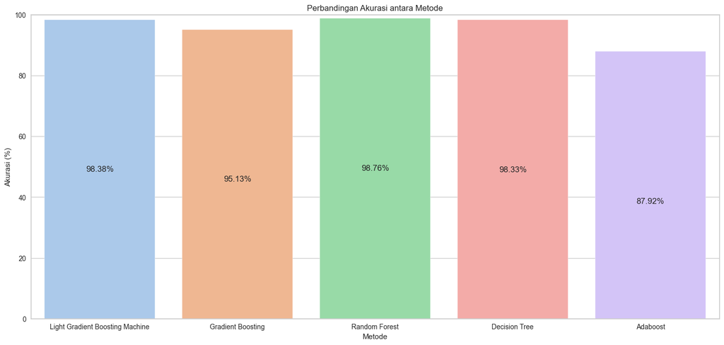

```python
methods = ['Light Gradient Boosting Machine', 'Gradient Boosting', 'Random Forest', 'Decision Tree', 'Adaboost']

# Daftar akurasi dari setiap metode
accuracies = [accuracy_lightgbm*100, accuracy_gbc*100, accuracy_rf*100, accuracy_dt*100, accuracy_ada*100]

# Membuat dataframe dari data
data = {'Metode': methods, 'Akurasi (%)': accuracies}
dataa = pd.DataFrame(data)

# Membuat grafik bar dengan Seaborn
plt.figure(figsize=(18, 8))
ax = sns.barplot(x='Metode', y='Akurasi (%)', data=dataa, palette='pastel')
plt.xlabel('Metode')
plt.ylabel('Akurasi (%)')
plt.title('Perbandingan Akurasi antara Metode')
plt.ylim(0, 100)
# Menambahkan nilai-nilai akurasi di atas setiap batang
for index, value in enumerate(accuracies):
    plt.text(index, value - 50, f'{value:.2f}%', ha='center', fontsize=12)

plt.show()
```

# Evaluasi

Evaluasi dalam konteks model prediktif dan klasifikasi merujuk pada penilaian kinerja model terhadap data yang belum pernah dilihat sebelumnya atau data uji. Tujuan evaluasi adalah untuk memahami sejauh mana model dapat menggeneralis ke data baru dan seberapa baik model dapat melakukan tugasnya, seperti klasifikasi dengan akurasi tinggi atau regresi dengan presisi yang baik. Confusion matrix adalah sebuah tabel yang digunakan dalam evaluasi kinerja model klasifikasi untuk memahami performa model dalam memprediksi kelas-kelas target. Matrix ini memiliki empat sel yang mewakili:

1. True Positive (TP): Prediksi yang benar ketika kelas sebenarnya adalah positif.
2. True Negative (TN): Prediksi yang benar ketika kelas sebenarnya adalah negatif.
3. False Positive (FP): Prediksi yang salah ketika model memprediksi positif tetapi kelas sebenarnya negatif (juga dikenal sebagai Type I error).
4. False Negative (FN): Prediksi yang salah ketika model memprediksi negatif tetapi kelas sebenarnya positif (juga dikenal sebagai Type II error).

Bentuk dari tabel Confusion Matrix

|  | Predicted Negative | Predicted Positive |
| --- | --- | --- |
| Actual Negative | True Negative (TN) | False Positive (FP) |
| Actual Positive | False Negative (FN) | True Positive (TP) |

Dari Confusion Matriks, kta dapat menghitung metrik evaluasi seperti akurasi, presisi, recall, F1-score, dan lainnya yang membantu dalam mengevaluasi performa model klasifikasi. Berikut adalah beberapa metrik evaluasi umum:

1. Akurasi (Accuracy) mengukur sejauh mana model dapat mengklasifikasikan data dengan benar. Akurasi dinyatakan sebagai persentase dari total prediksi yang benar. $$\text{Accuracy} = \frac{\text{True Positive} + \text{True Negative}}{\text{Total Data}}$$
2. Recall (Sensitivitas atau True Positive Rate) mengukur sejauh mana model dapat mengidentifikasi semua instance yang benar positif dari kelas tertentu. Recall berguna ketika menghindari false negatives sangat penting. $$\text{Recall} = \frac{\text{True Positive}}{\text{True Positive} + \text{False Negative}}$$
3. Precision mengukur sejauh mana prediksi positif model yang benar-benar benar. Precision berguna ketika menghindari false positives sangat penting. $$\text{Precision} = \frac{\text{True Positive}}{\text{True Positive} + \text{False Positive}}$$
4. F1 Score adalah harmonic mean dari precision dan recall. Ini memberikan keseimbangan antara precision dan recall. F1 Score tinggi menunjukkan keseimbangan yang baik antara precision dan recall. $$\text{F1 Score} = 2 \times \frac{\text{Precision} \times \text{Recall}}{\text{Precision} + \text{Recall}}$$
5. Classification Report:
   - Menyajikan statistik klasifikasi seperti precision, recall, dan f1-score untuk setiap kelas.
   - Dalam classification report, Anda akan mendapatkan informasi ini untuk setiap kelas.

## Light Gradient Boosting Machine

```
              precision    recall  f1-score   support

           0       1.00      0.97      0.98      1039
           1       0.97      1.00      0.98      1056

    accuracy                           0.98      2095
   macro avg       0.98      0.98      0.98      2095
weighted avg       0.98      0.98      0.98      2095
```

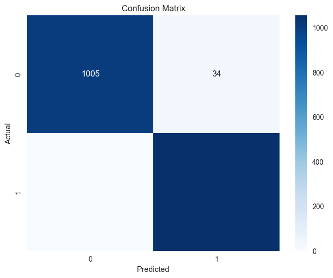

```python
from sklearn.metrics import classification_report
print(classification_report(y_test_lgbm, y_pred_lightgbm))
from sklearn.metrics import confusion_matrix

cm = confusion_matrix(y_test_lgbm, y_pred_lightgbm)
class_labels = np.unique(np.concatenate((y_test_lgbm, y_pred_lightgbm)))
plt.figure(figsize=(8, 6))
sns.heatmap(cm, annot=True, fmt="d", cmap="Blues", xticklabels=class_labels, yticklabels=class_labels)
plt.xlabel('Predicted')
plt.ylabel('Actual')
plt.title('Confusion Matrix')
plt.show()
```

- Presisi (Precision): Presisi mengukur akurasi dari prediksi positif yang dibuat oleh model. Dihitung sebagai jumlah true positives dibagi dengan jumlah true positives dan false positives. Untuk kelas 0: Presisi = 1,00 (100%) Untuk kelas 1: Presisi = 0,97 (97%) Presisi tinggi menunjukkan bahwa ketika model memprediksi kelas positif, kemungkinan prediksinya benar tinggi.
- Recall (Sensitivitas atau True Positive Rate): Recall mengukur kemampuan model untuk menangkap semua instance positif. Dihitung sebagai jumlah true positives dibagi dengan jumlah true positives dan false negatives. Untuk kelas 0: Recall = 0,97 (97%) Untuk kelas 1: Recall = 1,00 (100%) Recall tinggi menunjukkan bahwa model baik dalam mengidentifikasi instance positif.
- F1-Score: F1-Score adalah mean harmonik dari presisi dan recall. Memberikan keseimbangan antara presisi dan recall, terutama saat terdapat ketidakseimbangan distribusi kelas. Untuk kelas 0: F1-Score = 0,98 Untuk kelas 1: F1-Score = 0,98 F1-Score berguna saat ingin mempertimbangkan baik false positives maupun false negatives.
- Support: Support adalah jumlah kemunculan aktual dari kelas pada dataset tertentu. Untuk kelas 0: Support = 1039 Untuk kelas 1: Support = 1056 Akurasi:
- Akurasi akurasi adalah kebenaran keseluruhan dari model. Diitung sebagai jumlah true positives dan true negatives dibagi dengan total jumlah instance. Akurasi = 0,98 (98%) Macro Avg:
- Macro-average menghitung kinerja rata-rata across semua kelas tanpa mempertimbangkan ketidakseimbangan kelas. Macro Avg Presisi = 0,98 Macro Avg Recall = 0,98 Macro Avg F1-Score = 0,98 Weighted Avg:
- Weighted-average mempertimbangkan ketidakseimbangan kelas dan menghitung kinerja rata-rata, diberi bobot oleh jumlah instance pada setiap kelas. Weighted Avg Presisi = 0,98 Weighted Avg Recall = 0,98 Weighted Avg F1-Score = 0,98

Secara keseluruhan, model Anda sangat baik, mencapai presisi, recall, dan F1-Score tinggi untuk kedua kelas. Akurasi keseluruhan sebesar 98% menunjukkan bahwa model akurat dalam memprediksi kedua instance positif dan negatif. Nilai macro dan weighted average yang tinggi menunjukkan bahwa model mampu mengatasi ketidakseimbangan kelas.

## Gradient Boosting Classifier

```
              precision    recall  f1-score   support

           0       0.97      0.93      0.95      1039
           1       0.93      0.97      0.95      1056

    accuracy                           0.95      2095
   macro avg       0.95      0.95      0.95      2095
weighted avg       0.95      0.95      0.95      2095
```

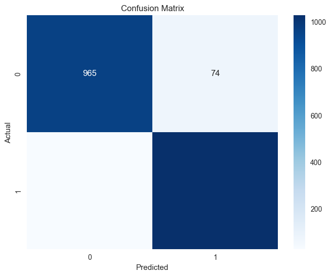

```python
from sklearn.metrics import classification_report
print(classification_report(y_test_gbc, y_pred_gbc))
from sklearn.metrics import confusion_matrix

cm = confusion_matrix(y_test_gbc, y_pred_gbc)
class_labels = np.unique(np.concatenate((y_test_gbc, y_pred_gbc)))
plt.figure(figsize=(8, 6))
sns.heatmap(cm, annot=True, fmt="d", cmap="Blues", xticklabels=class_labels, yticklabels=class_labels)
plt.xlabel('Predicted')
plt.ylabel('Actual')
plt.title('Confusion Matrix')
plt.show()
```

- Presisi : Presisi mengukur ketepatan model dalam memprediksi kelas positif. Untuk kelas 0: Presisi = 0,97 (97%) Untuk kelas 1: Presisi = 0,93 (93%) Presisi yang tinggi menunjukkan bahwa ketika model memprediksi kelas tertentu, prediksinya cenderung benar.
- Recall (Sensitivitas atau True Positive Rate): Recall mengukur kemampuan model untuk menemukan semua instance kelas positif. Untuk kelas 0: Recall = 0,93 (93%) Untuk kelas 1: Recall = 0,97 (97%) Recall yang tinggi menunjukkan bahwa model cenderung mengidentifikasi sebagian besar instance yang seharusnya termasuk dalam kelas positif.
- F1-Score: F1-Score adalah mean harmonik dari presisi dan recall. Untuk kelas 0: F1-Score = 0,95 Untuk kelas 1: F1-Score = 0,95 F1-Score memberikan keseimbangan antara presisi dan recall, dan nilai tinggi menunjukkan performa yang baik.
- Support: Support adalah jumlah instance aktual dari kelas pada dataset tertentu. Untuk kelas 0: Support = 1039 Untuk kelas 1: Support = 1056
- Akurasi (Accuracy): Akurasi mengukur keseluruhan ketepatan model. Akurasi = 0,95 (95%) Akurasi yang tinggi menunjukkan bahwa model secara keseluruhan memiliki performa yang baik.
- Macro Avg: Macro-average menghitung rata-rata performa untuk semua kelas tanpa mempertimbangkan ketidakseimbangan kelas. Macro Avg Presisi = 0,95 Macro Avg Recall = 0,95 Macro Avg F1-Score = 0,95
- Weighted Avg: Weighted-average mempertimbangkan ketidakseimbangan kelas dan menghitung rata-rata performa, diberi bobot oleh jumlah instance pada setiap kelas. Weighted Avg Presisi = 0,95 Weighted Avg Recall = 0,95 Weighted Avg F1-Score = 0,95

Dengan nilai yang tinggi pada presisi, recall, dan F1-score, serta akurasi 95%, dapat disimpulkan bahwa model ini memiliki kinerja yang baik dalam melakukan klasifikasi untuk kedua kelasnya.

## Random Forest

```
              precision    recall  f1-score   support

           0       1.00      0.97      0.99      1039
           1       0.98      1.00      0.99      1056

    accuracy                           0.99      2095
   macro avg       0.99      0.99      0.99      2095
weighted avg       0.99      0.99      0.99      2095
```

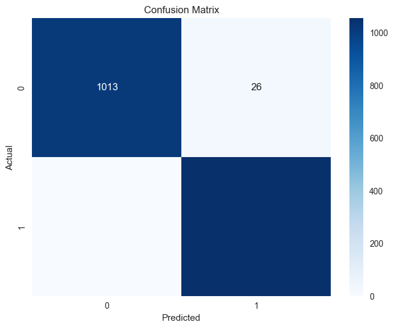

```python
from sklearn.metrics import classification_report
print(classification_report(y_test_rf, y_pred_rf))
from sklearn.metrics import confusion_matrix

cm = confusion_matrix(y_test_rf, y_pred_rf)
class_labels = np.unique(np.concatenate((y_test_rf, y_pred_rf)))
plt.figure(figsize=(8, 6))
sns.heatmap(cm, annot=True, fmt="d", cmap="Blues", xticklabels=class_labels, yticklabels=class_labels)
plt.xlabel('Predicted')
plt.ylabel('Actual')
plt.title('Confusion Matrix')
plt.show()
```

- Presisi (Precision): Presisi mengukur ketepatan model dalam memprediksi kelas positif. Untuk kelas 0: Presisi = 1,00 (100%) Untuk kelas 1: Presisi = 0,98 (98%) Presisi yang tinggi menunjukkan bahwa model jarang membuat kesalahan ketika memprediksi kelas tertentu.
- Recall (Sensitivitas atau True Positive Rate): Recall mengukur kemampuan model untuk menemukan semua instance kelas positif. Untuk kelas 0: Recall = 0,97 (97%) Untuk kelas 1: Recall = 1,00 (100%) Recall yang tinggi menunjukkan bahwa model berhasil mengidentifikasi hampir semua instance yang seharusnya termasuk dalam kelas positif.
- F1-Score: F1-Score adalah mean harmonik dari presisi dan recall. Untuk kelas 0: F1-Score = 0,99 Untuk kelas 1: F1-Score = 0,99 F1-Score yang tinggi menunjukkan keseimbangan yang baik antara presisi dan recall.
- Support: Support adalah jumlah instance aktual dari kelas pada dataset tertentu. Untuk kelas 0: Support = 1039 Untuk kelas 1: Support = 1056
- Akurasi (Accuracy): Akurasi mengukur keseluruhan ketepatan model. Akurasi = 0,99 (99%) Akurasi yang sangat tinggi menunjukkan bahwa model ini memiliki kinerja yang sangat baik dalam melakukan klasifikasi.
- Macro Avg: Macro-average menghitung rata-rata performa untuk semua kelas tanpa mempertimbangkan ketidakseimbangan kelas. Macro Avg Presisi = 0,99 Macro Avg Recall = 0,99 Macro Avg F1-Score = 0,99
- Weighted Avg: Weighted-average mempertimbangkan ketidakseimbangan kelas dan menghitung rata-rata performa, diberi bobot oleh jumlah instance pada setiap kelas. Weighted Avg Presisi = 0,99 Weighted Avg Recall = 0,99 Weighted Avg F1-Score = 0,99

Secara keseluruhan, model ini memiliki performa sangat baik dengan nilai presisi, recall, dan F1-Score yang tinggi untuk kedua kelasnya. Akurasi yang mencapai 99% menunjukkan kemampuan model dalam melakukan klasifikasi dengan tingkat kesalahan yang sangat rendah.

## Decision Tree Clasifier

```
              precision    recall  f1-score   support

           0       1.00      0.97      0.98      1039
           1       0.97      1.00      0.98      1056

    accuracy                           0.98      2095
   macro avg       0.98      0.98      0.98      2095
weighted avg       0.98      0.98      0.98      2095
```

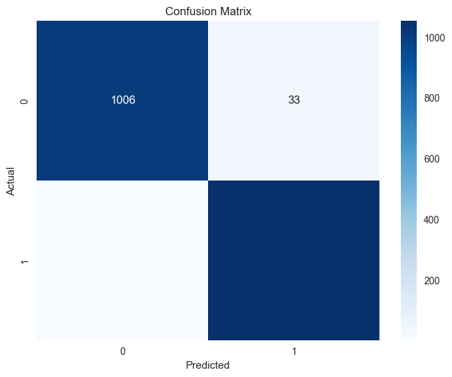

```python
from sklearn.metrics import classification_report
print(classification_report(y_test_dt, y_pred_dt))
from sklearn.metrics import confusion_matrix

cm = confusion_matrix(y_test_dt, y_pred_dt)
class_labels = np.unique(np.concatenate((y_test_dt, y_pred_dt)))
plt.figure(figsize=(8, 6))
sns.heatmap(cm, annot=True, fmt="d", cmap="Blues", xticklabels=class_labels, yticklabels=class_labels)
plt.xlabel('Predicted')
plt.ylabel('Actual')
plt.title('Confusion Matrix')
plt.show()
```

- Presisi (Precision): Presisi mengukur ketepatan model dalam memprediksi kelas positif. Untuk kelas 0: Presisi = 1,00 (100%) Untuk kelas 1: Presisi = 0,97 (97%) Presisi yang tinggi menunjukkan bahwa model jarang membuat kesalahan ketika memprediksi kelas tertentu.
- Recall (Sensitivitas atau True Positive Rate): Recall mengukur kemampuan model untuk menemukan semua instance kelas positif. Untuk kelas 0: Recall = 0,97 (97%) Untuk kelas 1: Recall = 1,00 (100%) Recall yang tinggi menunjukkan bahwa model berhasil mengidentifikasi hampir semua instance yang seharusnya termasuk dalam kelas positif.
- F1-Score: F1-Score adalah mean harmonik dari presisi dan recall. Untuk kelas 0: F1-Score = 0,98 Untuk kelas 1: F1-Score = 0,98 F1-Score yang tinggi menunjukkan keseimbangan yang baik antara presisi dan recall.
- Support: Support adalah jumlah instance aktual dari kelas pada dataset tertentu. Untuk kelas 0: Support = 1039 Untuk kelas 1: Support = 1056
- Akurasi (Accuracy): Akurasi mengukur keseluruhan ketepatan model. Akurasi = 0,98 (98%) Akurasi yang tinggi menunjukkan bahwa model ini memiliki kinerja yang sangat baik dalam melakukan klasifikasi.
- Macro Avg: Macro-average menghitung rata-rata performa untuk semua kelas tanpa mempertimbangkan ketidakseimbangan kelas. Macro Avg Presisi = 0,98 Macro Avg Recall = 0,98 Macro Avg F1-Score = 0,98
- Weighted Avg: Weighted-average mempertimbangkan ketidakseimbangan kelas dan menghitung rata-rata performa, diberi bobot oleh jumlah instance pada setiap kelas. Weighted Avg Presisi = 0,98 Weighted Avg Recall = 0,98 Weighted Avg F1-Score = 0,98

Secara keseluruhan, model ini telah memberikan hasil yang sangat baik dengan nilai presisi, recall, dan F1-Score yang tinggi untuk kedua kelasnya. Akurasi sebesar 98% menunjukkan kemampuan model dalam melakukan klasifikasi dengan sangat baik.

## Ada Boost Classifier

```
              precision    recall  f1-score   support

           0       0.87      0.89      0.88      1039
           1       0.89      0.87      0.88      1056

    accuracy                           0.88      2095
   macro avg       0.88      0.88      0.88      2095
weighted avg       0.88      0.88      0.88      2095
```

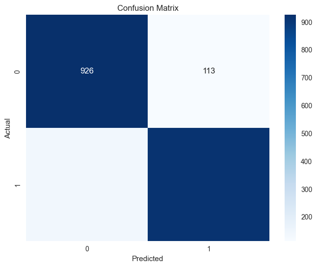

```python
from sklearn.metrics import classification_report
print(classification_report(y_test_ada, y_pred_ada))
from sklearn.metrics import confusion_matrix

cm = confusion_matrix(y_test_ada, y_pred_ada)
class_labels = np.unique(np.concatenate((y_test_ada, y_pred_ada)))
plt.figure(figsize=(8, 6))
sns.heatmap(cm, annot=True, fmt="d", cmap="Blues", xticklabels=class_labels, yticklabels=class_labels)
plt.xlabel('Predicted')
plt.ylabel('Actual')
plt.title('Confusion Matrix')
plt.show()
```

- Presisi (Precision): Presisi mengukur ketepatan model dalam memprediksi kelas positif. Untuk kelas 0: Presisi = 0,87 (87%) Untuk kelas 1: Presisi = 0,89 (89%) Presisi yang baik menunjukkan bahwa ketika model memprediksi kelas tertentu, kemungkinan prediksinya benar tinggi.
- Recall (Sensitivitas atau True Positive Rate): Recall mengukur kemampuan model untuk menemukan semua instance kelas positif. Untuk kelas 0: Recall = 0,89 (89%) Untuk kelas 1: Recall = 0,87 (87%) Recall yang seimbang menunjukkan bahwa model berhasil mengidentifikasi sebagian besar instance yang seharusnya termasuk dalam kelas positif.
- F1-Score: F1-Score adalah mean harmonik dari presisi dan recall. Untuk kelas 0: F1-Score = 0,88 Untuk kelas 1: F1-Score = 0,88 F1-Score yang seimbang menunjukkan keseimbangan yang baik antara presisi dan recall.
- Support: Support adalah jumlah instance aktual dari kelas pada dataset tertentu. Untuk kelas 0: Support = 1039 Untuk kelas 1: Support = 1056
- Akurasi (Accuracy): Akurasi mengukur keseluruhan ketepatan model. Akurasi = 0,88 (88%) Meskipun tidak setinggi pada kasus sebelumnya, akurasi 88% masih menunjukkan kinerja model yang baik.
- Macro Avg: Macro-average menghitung rata-rata performa untuk semua kelas tanpa mempertimbangkan ketidakseimbangan kelas. Macro Avg Presisi = 0,88 Macro Avg Recall = 0,88 Macro Avg F1-Score = 0,88
- Weighted Avg: Weighted-average mempertimbangkan ketidakseimbangan kelas dan menghitung rata-rata performa, diberi bobot oleh jumlah instance pada setiap kelas. Weighted Avg Presisi = 0,88 Weighted Avg Recall = 0,88 Weighted Avg F1-Score = 0,88

Secara keseluruhan, model ini memberikan hasil yang baik dengan presisi, recall, dan F1-Score yang seimbang untuk kedua kelasnya. Akurasi sebesar 88% menunjukkan kemampuan model dalam melakukan klasifikasi dengan tingkat kesalahan yang relatif rendah.

# Deployment

Silahkan klik [Disini](https://mubessirulummah-waterquality.streamlit.app/) untuk melihat deploynya.

# Prediksi

selanjutnya kita akan coba melakukan prediksi melalui model yang telah kita buat sebelumnya.

## Light Gradient Boosting Machine

```python
import joblib
import pandas as pd

print("🌊 Water Quality Prediction Light Gradient Boosting Machine")

# Load the features used in the model
fitur = joblib.load('fiturLightGradientBoostingMachine.pkl')
print(fitur)

# Input values
aluminium = float(input("Kandungan Aluminium : "))
ammonia = float(input("Kandungan Ammonia : "))
arsenic = float(input("Kandungan Arsenic : "))
barium = float(input("Kandungan Barium : "))
cadmium = float(input("Kandungan Cadmium : "))
chloramine = float(input("Kandungan Chloramine : "))
chromium = float(input("Kandungan Chromium : "))
copper = float(input("Kandungan Tembaga : "))
flouride = float(input("Kandungan Flourida : "))
bacteria = float(input("Kandungan Bakteri : "))
viruses = float(input("Kandungan Virus : "))
lead = float(input("Kandungan Timbal : "))
nitrates = float(input("Kandungan Nitrat : "))
nitrites = float(input("Kandungan Nitrit : "))
mercury = float(input("Kandungan Mercuri : "))
perchlorate = float(input("Kandungan Perchlorate : "))
radium = float(input("Kandungan Radium : "))
selenium = float(input("Kandungan Selenium : "))
silver = float(input("Kandungan Perak : "))
uranium = float(input("Kandungan Uranium : "))

# Create a DataFrame with the input data
data = {'aluminium': aluminium,
        'ammonia': ammonia,
        'arsenic': arsenic,
        'barium': barium,
        'cadmium': cadmium,
        'chloramine': chloramine,
        'chromium': chromium,
        'copper': copper,
        'flouride': flouride,
        'bacteria': bacteria,
        'viruses': viruses,
        'lead': lead,
        'nitrates': nitrates,
        'nitrites': nitrites,
        'mercury': mercury,
        'perchlorate': perchlorate,
        'radium': radium,
        'selenium': selenium,
        'silver': silver,
        'uranium': uranium}

data_implementasi = pd.DataFrame([data])

# Load the scaler
scaler = joblib.load('saclelightgbm.pkl')

# Scale the input data
data_uji_scaled = scaler.transform(data_implementasi)

# Load the model
lightgbmmodel = joblib.load('modellightgbm.pkl')

# Make predictions
prediksi = lightgbmmodel.predict(data_uji_scaled)

if prediksi == 0:
    print('Hasil Prediksi : not safe')
elif prediksi == 1:
    print('Hasil Prediksi : safe')
```

```
🌊 Water Quality Prediction Light Gradient Boosting Machine
Index(['aluminium', 'ammonia', 'arsenic', 'barium', 'cadmium', 'chloramine',
       'chromium', 'copper', 'flouride', 'bacteria', 'viruses', 'lead',
       'nitrates', 'nitrites', 'mercury', 'perchlorate', 'radium', 'selenium',
       'silver', 'uranium'],
      dtype='object')
Kandungan Aluminium : 0.9
Kandungan Ammonia : 0.32
Kandungan Arsenic : 0.2
Kandungan Barium : 0.1
Kandungan Cadmium : 0.2
Kandungan Chloramine : 0.132
Kandungan Chromium : 3
Kandungan Tembaga : 0.2
Kandungan Flourida : 0.43
Kandungan Bakteri : 0.4
Kandungan Virus : 0.3
Kandungan Timbal : 1
Kandungan Nitrat : 0
Kandungan Nitrit : 0.3
Kandungan Mercuri : 0.7
Kandungan Perchlorate : 0.5
Kandungan Radium : 0.5
Kandungan Selenium : 0.34
Kandungan Perak : 0.1
Kandungan Uranium : 3
Hasil Prediksi : not safe
```

## Gradient Boosting Classifier

```python
import joblib
import pandas as pd

print("🌊 Water Quality Prediction Gradient Boosting")

fitur = joblib.load('fiturgradientboosting.pkl')
print(fitur)

aluminium = float(input("Kandungan Aluminium : "))
ammonia = float(input("Kandungan Ammonia : "))
arsenic = float(input("Kandungan Arsenic : "))
barium = float(input("Kandungan Barium : "))
cadmium = float(input("Kandungan Cadmium : "))
chloramine = float(input("Kandungan Chloramine : "))
chromium = float(input("Kandungan Chromium : "))
copper = float(input("Kandungan Tembaga : "))
flouride = float(input("Kandungan Flourida : "))
bacteria = float(input("Kandungan Bakteri : "))
viruses = float(input("Kandungan Virus : "))
lead = float(input("Kandungan Timbal : "))
nitrates = float(input("Kandungan Nitrat : "))
nitrites = float(input("Kandungan Nitrit : "))
mercury = float(input("Kandungan Mercuri : "))
perchlorate = float(input("Kandungan Perchlorate : "))
radium = float(input("Kandungan Radium : "))
selenium = float(input("Kandungan Selenium : "))
silver = float(input("Kandungan Perak : "))
uranium = float(input("Kandungan Uranium : "))

results = []
data = {'aluminium': aluminium,
        'ammonia': ammonia,
        'arsenic': arsenic,
        'barium': barium,
        'cadmium': cadmium,
        'chloramine': chloramine,
        'chromium': chromium,
        'copper': copper,
        'flouride': flouride,
        'bacteria': bacteria,
        'viruses': viruses,
        'lead': lead,
        'nitrates': nitrates,
        'nitrites': nitrites,
        'mercury': mercury,
        'perchlorate': perchlorate,
        'radium': radium,
        'selenium': selenium,
        'silver': silver,
        'uranium': uranium}

data_implementasi = pd.DataFrame([data])

scaler = joblib.load('saclergbc.pkl')
data_uji_scaled = scaler.transform(data_implementasi)

# Load the model
gbcmodel = joblib.load('modelgbc.pkl')

# Make predictions
prediksi = gbcmodel.predict(data_uji_scaled)
if prediksi == 0:
    print('Hasil Prediksi : not safe')
elif prediksi == 1:
    print('Hasil Prediksi : safe')
```

```
🌊 Water Quality Prediction Gradient Boosting
Index(['aluminium', 'ammonia', 'arsenic', 'barium', 'cadmium', 'chloramine',
       'chromium', 'copper', 'flouride', 'bacteria', 'viruses', 'lead',
       'nitrates', 'nitrites', 'mercury', 'perchlorate', 'radium', 'selenium',
       'silver', 'uranium'],
      dtype='object')
Kandungan Aluminium : 0.1
Kandungan Ammonia : 0.2
Kandungan Arsenic : 0.1
Kandungan Barium : 0.32
Kandungan Cadmium : 0.4
Kandungan Chloramine : 0.2
Kandungan Chromium : 0.1
Kandungan Tembaga : 0.32
Kandungan Flourida : 1
Kandungan Bakteri : 0
Kandungan Virus : 0.3
Kandungan Timbal : 0.22
Kandungan Nitrat : 0.98
Kandungan Nitrit : 0.3
Kandungan Mercuri : 0.1
Kandungan Perchlorate : 2
Kandungan Radium : 0.3
Kandungan Selenium : 0.12
Kandungan Perak : 0.43
Kandungan Uranium : 0.5
Hasil Prediksi : not safe
```

## Random Forest

```python
import joblib
import pandas as pd

print("🌊 Water Quality Prediction Random Forest")

fitur = joblib.load('fiturrandomforest.pkl')
print(fitur)

aluminium = float(input("Kandungan Aluminium : "))
ammonia = float(input("Kandungan Ammonia : "))
arsenic = float(input("Kandungan Arsenic : "))
barium = float(input("Kandungan Barium : "))
cadmium = float(input("Kandungan Cadmium : "))
chloramine = float(input("Kandungan Chloramine : "))
chromium = float(input("Kandungan Chromium : "))
copper = float(input("Kandungan Tembaga : "))
viruses = float(input("Kandungan Virus : "))
nitrates = float(input("Kandungan Nitrat : "))
nitrites = float(input("Kandungan Nitrit : "))
mercury = float(input("Kandungan Mercuri : "))
perchlorate = float(input("Kandungan Perchlorate : "))
radium = float(input("Kandungan Radium : "))
selenium = float(input("Kandungan Selenium : "))
silver = float(input("Kandungan Perak : "))
uranium = float(input("Kandungan Uranium : "))

results = []
data = {'aluminium': aluminium,
        'ammonia': ammonia,
        'arsenic': arsenic,
        'barium': barium,
        'cadmium': cadmium,
        'chloramine': chloramine,
        'chromium': chromium,
        'copper': copper,
        'viruses': viruses,
        'nitrates': nitrates,
        'nitrites': nitrites,
        'mercury': mercury,
        'perchlorate': perchlorate,
        'radium': radium,
        'selenium': selenium,
        'silver': silver,
        'uranium': uranium}

data_implementasi = pd.DataFrame([data])

scaler = joblib.load('saclerrandomforest.pkl')
data_uji_scaled = scaler.transform(data_implementasi)

# Load the model
rfmodel = joblib.load('modelrandomforest.pkl')

# Make predictions
prediksi = rfmodel.predict(data_uji_scaled)
if prediksi == 0:
    print('Hasil Prediksi : not safe')
elif prediksi == 1:
    print('Hasil Prediksi : safe')
```

```
🌊 Water Quality Prediction Random Forest
Index(['aluminium', 'ammonia', 'arsenic', 'barium', 'cadmium', 'chloramine',
       'chromium', 'copper', 'viruses', 'nitrates', 'nitrites', 'mercury',
       'perchlorate', 'radium', 'selenium', 'silver', 'uranium'],
      dtype='object')
Kandungan Aluminium : 1
Kandungan Ammonia : 0.2
Kandungan Arsenic : 0.1
Kandungan Barium : 0.5
Kandungan Cadmium : 1
Kandungan Chloramine : 0.1
Kandungan Chromium : 0.1
Kandungan Tembaga : 0.1
Kandungan Virus : 0
Kandungan Nitrat : 0
Kandungan Nitrit : 0.1
Kandungan Mercuri : 0.1
Kandungan Perchlorate : 0
Kandungan Radium : 0
Kandungan Selenium : 0.1
Kandungan Perak : 0.1
Kandungan Uranium : 0
Hasil Prediksi : not safe
```

## Decision Tree Clasifier

```python
##### import joblib
import pandas as pd

print("🌊 Water Quality Prediction Decision Tree")

fitur = joblib.load('fiturdecisiontree.pkl')
print(fitur)

aluminium = float(input("Kandungan Aluminium : "))
ammonia = float(input("Kandungan Ammonia : "))
arsenic = float(input("Kandungan Arsenic : "))
barium = float(input("Kandungan Barium : "))
cadmium = float(input("Kandungan Cadmium : "))
chloramine = float(input("Kandungan Chloramine : "))
chromium = float(input("Kandungan Chromium : "))
copper = float(input("Kandungan Tembaga : "))
flouride = float(input("Kandungan Flourida : "))
bacteria = float(input("Kandungan Bakteri : "))
viruses = float(input("Kandungan Virus : "))
nitrates = float(input("Kandungan Nitrat : "))
nitrites = float(input("Kandungan Nitrit : "))
mercury = float(input("Kandungan Mercuri : "))
perchlorate = float(input("Kandungan Perchlorate : "))
radium = float(input("Kandungan Radium : "))
selenium = float(input("Kandungan Selenium : "))
silver = float(input("Kandungan Perak : "))
uranium = float(input("Kandungan Uranium : "))

results = []
data = {'aluminium': aluminium,
        'ammonia': ammonia,
        'arsenic': arsenic,
        'barium': barium,
        'cadmium': cadmium,
        'chloramine': chloramine,
        'chromium': chromium,
        'copper': copper,
        'flouride': flouride,
        'bacteria': bacteria,
        'viruses': viruses,
        'nitrates': nitrates,
        'nitrites': nitrites,
        'mercury': mercury,
        'perchlorate': perchlorate,
        'radium': radium,
        'selenium': selenium,
        'silver': silver,
        'uranium': uranium}

data_implementasi = pd.DataFrame([data])

scaler = joblib.load('saclerdecisiontree.pkl')
data_uji_scaled = scaler.transform(data_implementasi)

# Load the model
dtmodel = joblib.load('modeldecisiontree.pkl')

# Make predictions
prediksi = dtmodel.predict(data_uji_scaled)
if prediksi == 0:
    print('Hasil Prediksi : not safe')
elif prediksi == 1:
    print('Hasil Prediksi : safe')
```

```
🌊 Water Quality Prediction Decision Tree
Index(['aluminium', 'ammonia', 'arsenic', 'barium', 'cadmium', 'chloramine',
       'chromium', 'copper', 'flouride', 'bacteria', 'viruses', 'nitrates',
       'nitrites', 'mercury', 'perchlorate', 'radium', 'selenium', 'silver',
       'uranium'],
      dtype='object')
Kandungan Aluminium : 0.6
Kandungan Ammonia : 0.3
Kandungan Arsenic : 0.2
Kandungan Barium : 0.1
Kandungan Cadmium : 0.1
Kandungan Chloramine : 0.1
Kandungan Chromium : 3
Kandungan Tembaga : 0.3
Kandungan Flourida : 0.5
Kandungan Bakteri : 0.5
Kandungan Virus : 0
Kandungan Nitrat : 0
Kandungan Nitrit : 0
Kandungan Mercuri : 0.2
Kandungan Perchlorate : 0.1
Kandungan Radium : 0.1
Kandungan Selenium : 0.1
Kandungan Perak : 0.3
Kandungan Uranium : 0.2
Hasil Prediksi : not safe
```

## Ada Boost Classifier

```python
import joblib
import pandas as pd

print("🌊 Water Quality Prediction Adaboost")

fitur = joblib.load('fituradaboost.pkl')
print(fitur)

aluminium = float(input("Kandungan Aluminium : "))
ammonia = float(input("Kandungan Ammonia : "))
arsenic = float(input("Kandungan Arsenic : "))
barium = float(input("Kandungan Barium : "))
cadmium = float(input("Kandungan Cadmium : "))
chloramine = float(input("Kandungan Chloramine : "))
chromium = float(input("Kandungan Chromium : "))
copper = float(input("Kandungan Tembaga : "))
flouride = float(input("Kandungan Flourida : "))
bacteria = float(input("Kandungan Bakteri : "))
viruses = float(input("Kandungan Virus : "))
lead = float(input("Kandungan Timbal : "))
nitrates = float(input("Kandungan Nitrat : "))
nitrites = float(input("Kandungan Nitrit : "))
mercury = float(input("Kandungan Mercuri : "))
perchlorate = float(input("Kandungan Perchlorate : "))
radium = float(input("Kandungan Radium : "))
selenium = float(input("Kandungan Selenium : "))
silver = float(input("Kandungan Perak : "))
uranium = float(input("Kandungan Uranium : "))

results = []
data = {'aluminium': aluminium,
        'ammonia': ammonia,
        'arsenic': arsenic,
        'barium': barium,
        'cadmium': cadmium,
        'chloramine': chloramine,
        'chromium': chromium,
        'copper': copper,
        'flouride': flouride,
        'bacteria': bacteria,
        'viruses': viruses,
        'lead': lead,
        'nitrates': nitrates,
        'nitrites': nitrites,
        'mercury': mercury,
        'perchlorate': perchlorate,
        'radium': radium,
        'selenium': selenium,
        'silver': silver,
        'uranium': uranium}

data_implementasi = pd.DataFrame([data])

scaler = joblib.load('sacleradaboost.pkl')
data_uji_scaled = scaler.transform(data_implementasi)

# Load the model
adamodel = joblib.load('modeladaboost.pkl')

# Make predictions
prediksi = adamodel.predict(data_uji_scaled)
if prediksi == 0:
    print('Hasil Prediksi : not safe')
elif prediksi == 1:
    print('Hasil Prediksi : safe')
```

```
🌊 Water Quality Prediction Adaboost
Index(['aluminium', 'ammonia', 'arsenic', 'barium', 'cadmium', 'chloramine',
       'chromium', 'copper', 'flouride', 'bacteria', 'viruses', 'lead',
       'nitrates', 'nitrites', 'mercury', 'perchlorate', 'radium', 'selenium',
       'silver', 'uranium'],
      dtype='object')
Kandungan Aluminium : 0.8
Kandungan Ammonia : 0.2
Kandungan Arsenic : 0.1
Kandungan Barium : 0.3
Kandungan Cadmium : 0.4
Kandungan Chloramine : 0.6
Kandungan Chromium : 5
Kandungan Tembaga : 0.5
Kandungan Flourida : 0.5
Kandungan Bakteri : 1
Kandungan Virus : 1
Kandungan Timbal : 0
Kandungan Nitrat : 0
Kandungan Nitrit : 0
Kandungan Mercuri : 0
Kandungan Perchlorate : 0.2
Kandungan Radium : 0.1
Kandungan Selenium : 0.3
Kandungan Perak : 0.1
Kandungan Uranium : 0.1
Hasil Prediksi : safe
```